# The mother of all X

Stefan Hartmann,Tobias Ungerer

11 December, 2021

## Preliminaries

Install and load packages

```r
# install CRAN packages (if not yet installed)
sapply(c("data.table", "tidyverse", "devtools", "readxl", "kableExtra", "ngram", "networkD3", "igraph", "network", "patchwork", "koRpus", "pbapply", "tidytext", "cluster", "ggrepel", "animation"), function(x) if(!is.element(x, installed.packages())) install.packages(x, dependencies = T))
```

```r
# install non-CRAN packages (if not yet installed)
if(!is.element("concordances", installed.packages())) {
devtools::install_github("hartmast/concordances")
}

# if this doesn't work, check sfla.ch for the package
if(!is.element("collostructions", installed.packages())) {
  install.packages("https://sfla.ch/wp-content/uploads/2021/02/collostructions_0.2.0.tar.gz", repos = NULL)
}


# install "concordances" if not yet installed
if(!is.element("concordances", installed.packages())) {
  devtools::install_github("hartmast/concordances", ref = "f4ca785
")
}

# load "concordances"
library(concordances)
library(tidyverse)
library(readxl)
library(data.table)
library(kableExtra)
library(collostructions)
```

# ENCOW

## Data retrieval

The data were retrieved from the NoSketchEngine instance of the COW corpora (https://www.webcorpora.org/) on Sept 27, 2019, using the ENCOW16B “World Englishes” corpus. The query was:

```r
[word="[Tt]he"] "mother" "of" "all" []
```

The data were exported to the XML file mother_of_all.xml, which is imported in the subsequent step.

```r
d <- getNSE("mother_of_all.xml", xml = TRUE, context_tags = FALSE, verbose = FALSE)
```

## Annotation

The concordance is exported for annotation, the annotated file is then read in.

```r
# write_excel_csv(d, "mother_of_all_ENCOW.csv")
d <- read_xlsx("mother_of_all_ENCOW.xlsx")
```

## Data wrangling

We only keep the instances manually tagged as keep == “y”, excluding false hits and doubtful cases.

```r
d <- filter(d, keep == "y")
```

## Types, tokens, hapax legomena

```r
# frequency table
d_tbl <- d %>% select(lemma) %>% table %>% as_tibble() %>% rename(c(lemma = ".", Freq = "n")) %>% arrange(desc(Freq))

# overview table

tibble(
  # types
  Types = nrow(d_tbl),

  # tokens
  Tokens = sum(d_tbl$Freq),

# hapax legomena
  "Hapax Legomena" = length(which(d_tbl$Freq==1))
) %>% kbl() %>% kable_material(c("striped", "hover"))
```

| Types | Tokens | Hapax Legomena |
| --- | --- | --- |
| 1669 | 4127 | 1092 |

## Collostructional analysis

For performing a collostructional analysis, we have to know how often a lemma attested in the open slot of the *mother of all* construction occurs in the ENCOW corpus as a whole. For this purpose, we read in the ENCOW word list (available at [webcorpora.org](https://www.webcorpora.org/opendata/frequencies/english/)).

```r
encow <- fread("/Volumes/My Passport/ENCOW word lists/encow16ax.lp.tsv",
               header = F)
#
# head(encow)
#
# # only nouns
# encow <- encow[V2 %in% c("NN", "NE")]
#
# head(encow)
```

```r
# only nouns
encow <- encow[V2 %in% c("NN", "NE")]
colnames(encow) <- c("Lemma", "POS", "Freq")

# if something is attested both as NN and
# NE, sum them up
encow <- encow[, sum(Freq), by = Lemma]
setnames(encow, old = "V1", new = "Freq")
```

We compile a frequency table from our *mother of all* concordance `d` and combine it with the corpus frequencies in the `encow` table.

```r
# get frequencies
d_tbl <- d %>% select(lemma) %>% table %>% sort(decreasing = T) %>%
  as.data.frame(stringsAsFactors = F)
colnames(d_tbl) <- c("Lemma", "Freq_in_cxn")

# join tables
d_tbl <- left_join(d_tbl, encow, by = "Lemma")
```

These data are not without noise - ENCOW’s lemmatization is of course not perfect, but we can still expect that the relationships between construction frequencies and corpus frequencies of the words in question are roughly representative of their “actual” relationship in everyday use, at least in the text types represented in the corpus. However, given that the lemmatization is not perfect, there can be cases where the corpus frequency is lower than the construction frequency. This is of course not possible - if a word occurs, say, three times in a specific construction in corpus, its total frequency in the corpus cannot be lower than three! In one instance, however, this is the case in our data. The reason for this is that our concordance was lemmatized manually while for ENCOW, we rely on the automatic lemmatization. As this only affects one single attestation, we just exclude it.

```r
# omit one case where corpus frequency is
# smaller than cxn frequency
d_tbl <- subset(d_tbl, d_tbl[,2] <= d_tbl[,3])
```

Next, we perform a collexeme analysis using Flach’s `collostructions` package.

```r
# sum(encow$Freq): 1312973874

# perform collexeme analysis
collex(d_tbl, corpsize = 1312973874) %>% kbl() %>%
   kable_material(c("striped", "hover")) %>% scroll_box(width = "800px", height = "200px")
```

COLLEX

CORP.FREQ

OBS

EXP

ASSOC

COLL.STR.LOGL

SIGNIF

battle

484438

148

1.5

attr

1072.75802

*****

hangover

14995

62

0.0

attr

770.22535

*****

bubble

96224

50

0.3

attr

413.92427

*****

crisis

505838

60

1.6

attr

321.93947

*****

bailout

33655

28

0.1

attr

257.89023

*****

headache

53912

29

0.2

attr

241.92209

*****

adventure

191789

34

0.6

attr

208.97021

*****

cock-up

1945

15

0.0

attr

204.91452

*****

bomb

146550

27

0.5

attr

167.94586

*****

storm

188133

28

0.6

attr

162.44206

*****

demo

90326

22

0.3

attr

148.92375

*****

scandal

90650

20

0.3

attr

131.47186

*****

evil

151141

22

0.5

attr

126.64401

*****

virtue

140524

20

0.4

attr

114.24151

*****

crash

171000

21

0.5

attr

113.90726

*****

tantrum

7269

10

0.0

attr

102.09407

*****

meltdown

24367

12

0.1

attr

97.94945

*****

sin

238017

20

0.7

attr

93.76021

*****

monad

6317

9

0.0

attr

92.51175

*****

recession

172604

18

0.5

attr

91.89608

*****

fuck-up

386

6

0.0

attr

90.40808

*****

festival

223809

19

0.7

attr

89.44341

*****

smokescreen

5221

8

0.0

attr

83.39349

*****

boom

91780

14

0.3

attr

81.84945

*****

jam

50678

12

0.2

attr

80.53389

*****

comeback

35080

11

0.1

attr

79.92964

*****

scam

54098

12

0.2

attr

78.98741

*****

party

1416961

33

4.4

attr

76.38306

*****

church

1084521

29

3.3

attr

74.13159

*****

vigil

12811

8

0.0

attr

69.07110

*****

war

1547825

32

4.8

attr

67.50411

*****

oxymoron

6864

7

0.0

attr

67.27827

*****

shitstorm

782

5

0.0

attr

66.41219

*****

parade

68237

11

0.2

attr

65.49409

*****

trip

657982

22

2.0

attr

65.02912

*****

irony

74469

11

0.2

attr

63.60957

*****

non-sequitur

1122

5

0.0

attr

62.79442

*****

thunderstorm

9474

7

0.0

attr

62.78072

*****

cliffhanger

4464

6

0.0

attr

60.97195

*****

mess-up

265

4

0.0

attr

60.03344

*****

run

501679

18

1.5

attr

55.50539

*****

theory

838156

22

2.6

attr

55.48564

*****

lie

115817

11

0.4

attr

54.14751

*****

democracy

326008

15

1.0

attr

53.14100

*****

stitch-up

635

4

0.0

attr

53.00913

*****

bollocking

727

4

0.0

attr

51.92408

*****

squeeze

24812

7

0.1

attr

49.39309

*****

migraine

14055

6

0.0

attr

47.26231

*****

extinction

50852

8

0.2

attr

47.24369

*****

pandemic

14329

6

0.0

attr

47.03227

*****

KPI

3

2

0.0

attr

46.93925

*****

whore

14594

6

0.0

attr

46.81395

*****

lawsuit

84644

9

0.3

attr

46.26814

*****

cold

97427

9

0.3

attr

43.81500

*****

engine

669812

17

2.1

attr

41.85177

*****

letdown

2667

4

0.0

attr

41.52173

*****

mashup

2703

4

0.0

attr

41.41460

*****

strike

221638

11

0.7

attr

40.51924

*****

facepalm

577

3

0.0

attr

38.60202

*****

conspiracy

131749

9

0.4

attr

38.59371

*****

rally

88735

8

0.3

attr

38.56859

*****

toothache

4236

4

0.0

attr

37.82785

*****

problem

2775608

32

8.6

attr

37.65172

*****

mandate

94348

8

0.3

attr

37.62173

*****

firewall

33507

6

0.1

attr

36.95531

*****

pothole

4735

4

0.0

attr

36.93962

*****

hazard

62851

7

0.2

attr

36.61396

*****

punch-up

826

3

0.0

attr

36.44632

*****

blowout

5973

4

0.0

attr

35.08841

*****

crunch

41359

6

0.1

attr

34.47704

*****

election

561752

14

1.7

attr

34.01035

*****

muck-up

55

2

0.0

attr

33.57554

*****

deal

891109

17

2.7

attr

33.50566

*****

distraction

45776

6

0.1

attr

33.28652

*****

compresser

74

2

0.0

attr

32.36965

*****

blizzard

9293

4

0.0

attr

31.57181

*****

conflict

429762

12

1.3

attr

31.55720

*****

burka

1961

3

0.0

attr

31.25931

*****

boondoggle

1962

3

0.0

attr

31.25625

*****

fest

9988

4

0.0

attr

30.99899

*****

prank

10039

4

0.0

attr

30.95855

*****

blog

872147

16

2.7

attr

30.48590

*****

backlash

29453

5

0.1

attr

30.27065

*****

vice

131

2

0.0

attr

30.06162

*****

ballgame

2596

3

0.0

attr

29.57900

*****

reorganisation

12120

4

0.0

attr

29.46407

*****

abomination

12732

4

0.0

attr

29.07368

*****

mess

174118

8

0.5

attr

28.30860

*****

raingear

211

2

0.0

attr

28.14379

*****

row

246058

9

0.8

attr

28.05294

*****

show

1223178

18

3.8

attr

27.85322

*****

isopod

230

2

0.0

attr

27.79745

*****

cover-up

15240

4

0.0

attr

27.65049

*****

disaster

254309

9

0.8

attr

27.51003

*****

rant

39624

5

0.1

attr

27.36670

*****

piss-up

272

2

0.0

attr

27.12412

*****

injunction

40964

5

0.1

attr

27.04234

*****

fundamentalism

16842

4

0.1

attr

26.86064

*****

spider

41755

5

0.1

attr

26.85595

*****

helter-skelter

345

2

0.0

attr

26.17047

*****

understatement

18688

4

0.1

attr

26.03988

*****

derby

18743

4

0.1

attr

26.01670

*****

demos

4734

3

0.0

attr

25.98581

*****

hoo-hah

369

2

0.0

attr

25.90085

*****

distortion

47320

5

0.1

attr

25.63902

*****

Frankenstorage

1

1

0.0

attr

25.37892

*****

install

1

1

0.0

attr

25.37892

*****

locker-upper

1

1

0.0

attr

25.37892

*****

p-tool

1

1

0.0

attr

25.37892

*****

pluck-up

1

1

0.0

attr

25.37892

*****

supervixen

1

1

0.0

attr

25.37892

*****

which

1

1

0.0

attr

25.37892

*****

struggle

301720

9

0.9

attr

24.72472

*****

bruise

5954

3

0.0

attr

24.61719

*****

whoredom

524

2

0.0

attr

24.49581

*****

invention

100412

6

0.3

attr

24.19633

*****

hormone

55263

5

0.2

attr

24.13617

*****

shipwreck

6932

3

0.0

attr

23.71049

*****

mother

1003158

15

3.1

attr

23.58403

*****

scare

26390

4

0.1

attr

23.32625

*****

monster

110701

6

0.3

attr

23.08905

*****

stunt

27271

4

0.1

attr

23.06895

*****

dust-up

758

2

0.0

attr

23.01813

*****

corruption

174984

7

0.5

attr

22.96894

*****

dealkiller

2

1

0.0

attr

22.60634

*****

no-partner

2

1

0.0

attr

22.60634

*****

hairball

967

2

0.0

attr

22.04421

*****

site

2681888

25

8.3

attr

21.91946

*****

bump

32671

4

0.1

attr

21.65682

*****

XenaFest

3

1

0.0

attr

21.55984

*****

fight

379255

9

1.2

attr

21.08517

*****

sulk

1257

2

0.0

attr

20.99591

*****

sandstorm

1341

2

0.0

attr

20.73747

*****

bashing

11621

3

0.0

attr

20.63887

*****

tsunami

37599

4

0.1

attr

20.56320

*****

APC

1404

2

0.0

attr

20.55409

*****

ctag

5

1

0.0

attr

20.37492

*****

paradox

40127

4

0.1

attr

20.05818

*****

flip-flop

1640

2

0.0

attr

19.93365

*****

scheme

643333

11

2.0

attr

19.66998

*****

backburn

7

1

0.0

attr

19.63733

*****

brainfade

7

1

0.0

attr

19.63733

*****

mom-mobile

7

1

0.0

attr

19.63733

*****

people

7

1

0.0

attr

19.63733

*****

pseudo-classification

7

1

0.0

attr

19.63733

*****

taxodium

7

1

0.0

attr

19.63733

*****

trap

89373

5

0.3

attr

19.53898

*****

bonfire

14085

3

0.0

attr

19.50014

riot

44101

4

0.1

attr

19.32716

deception

45742

4

0.1

attr

19.04499

secret

158973

6

0.5

attr

19.04345

nightmare

94890

5

0.3

attr

18.97396

herring

15446

3

0.0

attr

18.95504

mall

46373

4

0.1

attr

18.93927

cankle

11

1

0.0

attr

18.67699

soduko

11

1

0.0

attr

18.67699

garrison

16951

3

0.1

attr

18.40640

hike

49973

4

0.2

attr

18.36330

crawl

17169

3

0.1

attr

18.33107

play-down

13

1

0.0

attr

18.32807

protest

171612

6

0.5

attr

18.20326

biteback

15

1

0.0

attr

18.03110

growth-spurt

15

1

0.0

attr

18.03110

letterhack

15

1

0.0

attr

18.03110

coverup

2691

2

0.0

attr

17.95831

droner

16

1

0.0

attr

17.89768

binge

18595

3

0.1

attr

17.86109

backlog

18985

3

0.1

attr

17.73895

market

1956653

19

6.0

attr

17.69680

ROI

18

1

0.0

attr

17.65489

upset

19490

3

0.1

attr

17.58453

climb

55464

4

0.2

attr

17.56309

science

1150712

14

3.5

attr

17.55437

Spruance

19

1

0.0

attr

17.54373

gamble

20090

3

0.1

attr

17.40629

FMA

23

1

0.0

attr

17.15219

psych-out

23

1

0.0

attr

17.15219

dodo

3355

2

0.0

attr

17.07995

SUV

25

1

0.0

attr

16.98186

sandwich

60144

4

0.2

attr

16.94385

sinkhole

3493

2

0.0

attr

16.91952

miscalculation

3534

2

0.0

attr

16.87308

gad-fly

27

1

0.0

attr

16.82491

noria

28

1

0.0

attr

16.75082

towback

28

1

0.0

attr

16.75082

trade

761785

11

2.3

attr

16.68089

bitemark

29

1

0.0

attr

16.67939

shitfit

29

1

0.0

attr

16.67939

spoiler

23017

3

0.1

attr

16.60821

network

906418

12

2.8

attr

16.57921

movie

770612

11

2.4

attr

16.48176

GIL

33

1

0.0

attr

16.41671

stinkbomb

33

1

0.0

attr

16.41671

hoax

23836

3

0.1

attr

16.40346

self-martyrdom

35

1

0.0

attr

16.29728

coincidence

65767

4

0.2

attr

16.26346

hairdyer

36

1

0.0

attr

16.24013

delusion

24637

3

0.1

attr

16.21007

pseudo-scandal

37

1

0.0

attr

16.18458

zone-out

38

1

0.0

attr

16.13052

hug

25361

3

0.1

attr

16.04074

gubbing

40

1

0.0

attr

16.02661

upper-cut

41

1

0.0

attr

15.97661

reform

307536

7

0.9

attr

15.89053

bajada

44

1

0.0

attr

15.83371

souvlaki

45

1

0.0

attr

15.78825

rug

26496

3

0.1

attr

15.78504

super-heroine

49

1

0.0

attr

15.61612

swedge

49

1

0.0

attr

15.61612

queue

71668

4

0.2

attr

15.61239

tailchase

52

1

0.0

attr

15.49610

sale

549320

9

1.7

attr

15.46354

cameltoe

55

1

0.0

attr

15.38288

stuff-up

55

1

0.0

attr

15.38288

turd

5279

2

0.0

attr

15.27824

fiesta

5390

2

0.0

attr

15.19567

texaco

63

1

0.0

attr

15.10899

***

wiki

5682

2

0.0

attr

14.98640

***

lip-lock

67

1

0.0

attr

14.98494

***

NDA

67

1

0.0

attr

14.98494

***

northeaster

67

1

0.0

attr

14.98494

***

loofa

68

1

0.0

attr

14.95509

***

depression

232379

6

0.7

attr

14.93990

***

hooley

74

1

0.0

attr

14.78481

***

victory

337623

7

1.0

attr

14.76908

***

collapse

150197

5

0.5

attr

14.72229

***

wave

237780

6

0.7

attr

14.69745

***

awesomeness

6126

2

0.0

attr

14.68813

***

shocker

6199

2

0.0

attr

14.64119

***

meglomaniac

80

1

0.0

attr

14.62790

***

brain-teaser

81

1

0.0

attr

14.60291

***

hyperinflation

6371

2

0.0

attr

14.53276

***

short-covering

87

1

0.0

attr

14.45917

***

puzzle

83552

4

0.3

attr

14.45819

***

tirade

6608

2

0.0

attr

14.38810

***

downpour

6706

2

0.0

attr

14.32981

***

tank

353096

7

1.1

attr

14.23702

***

betrayal

34720

3

0.1

attr

14.21371

***

final

7070

2

0.0

attr

14.12059

***

rule-breaker

108

1

0.0

attr

14.02460

***

doodah

116

1

0.0

attr

13.88109

***

fart

7559

2

0.0

attr

13.85606

***

sell-out

7592

2

0.0

attr

13.83883

***

paralympics

119

1

0.0

attr

13.82983

***

pumpage

119

1

0.0

attr

13.82983

***

rip-off

7810

2

0.0

attr

13.72692

***

plague

38375

3

0.1

attr

13.63567

***

cyle

133

1

0.0

attr

13.60657

***

catch-up

8177

2

0.0

attr

13.54548

***

comet

39309

3

0.1

attr

13.49714

***

boy-toy

145

1

0.0

attr

13.43325

***

amusement

40014

3

0.1

attr

13.39482

***

shenanigan

149

1

0.0

attr

13.37866

***

gracilis

153

1

0.0

attr

13.32553

***

rollercoaster

8671

2

0.0

attr

13.31386

***

bitch

40726

3

0.1

attr

13.29338

***

hair-cut

167

1

0.0

attr

13.14995

***

beatboxer

171

1

0.0

attr

13.10250

***

kegger

172

1

0.0

attr

13.09081

***

scission

175

1

0.0

attr

13.05614

***

package

391297

7

1.2

attr

13.03410

***

stoppage

9622

2

0.0

attr

12.90341

***

weapon

184066

5

0.6

attr

12.89746

***

rigging

9650

2

0.0

attr

12.89196

***

pyramid

44491

3

0.1

attr

12.78605

***

MMO

203

1

0.0

attr

12.75869

***

mistake

287643

6

0.9

attr

12.72007

***

phish

210

1

0.0

attr

12.69076

***

gunbarrel

222

1

0.0

attr

12.57944

***

booksigning

225

1

0.0

attr

12.55255

***

malaprop

229

1

0.0

attr

12.51725

***

con

47005

3

0.1

attr

12.47173

***

foul-up

236

1

0.0

attr

12.45695

***

insult

47352

3

0.1

attr

12.42974

***

double-team

244

1

0.0

attr

12.39018

***

mindfuck

246

1

0.0

attr

12.37384

***

monsoon

11093

2

0.0

attr

12.34337

***

fisking

266

1

0.0

attr

12.21732

***

scramble

11805

2

0.0

attr

12.09890

***

goods

289

1

0.0

attr

12.05130

***

dinger

291

1

0.0

attr

12.03750

***

muse

12021

2

0.0

attr

12.02770

***

blockbuster

12153

2

0.0

attr

11.98483

***

fair

51271

3

0.2

attr

11.97678

***

flamewar

307

1

0.0

attr

11.93037

***

issue

1897553

16

5.9

attr

11.91619

***

gerrymander

310

1

0.0

attr

11.91091

***

river

431811

7

1.3

attr

11.90432

***

brunch

12536

2

0.0

attr

11.86307

***

AO

328

1

0.0

attr

11.79796

***

blackout

12872

2

0.0

attr

11.75933

***

bot

12957

2

0.0

attr

11.73352

***

comb-over

342

1

0.0

attr

11.71433

***

breakup

13065

2

0.0

attr

11.70098

***

city

1732174

15

5.3

attr

11.68156

***

sauce

122349

4

0.4

attr

11.64593

***

tongue-lashing

355

1

0.0

attr

11.63969

***

leak

54977

3

0.2

attr

11.58087

***

question

2122450

17

6.5

attr

11.56958

***

chilli

13570

2

0.0

attr

11.55239

***

carve-up

377

1

0.0

attr

11.51940

***

PWC

377

1

0.0

attr

11.51940

***

FPS

379

1

0.0

attr

11.50882

***

snowbank

386

1

0.0

attr

11.47221

***

broadband

125692

4

0.4

attr

11.45088

***

failure

585505

8

1.8

attr

11.43751

***

elephant

56787

3

0.2

attr

11.39767

***

self-promoter

401

1

0.0

attr

11.39596

***

artifacting

418

1

0.0

attr

11.31292

***

gyratory

428

1

0.0

attr

11.26564

***

tweaker

434

1

0.0

attr

11.23780

***

anticyclone

437

1

0.0

attr

11.22403

***

glitch

14897

2

0.0

attr

11.18735

***

tear-jerker

449

1

0.0

attr

11.16986

***

showdown

15042

2

0.0

attr

11.14949

***

jeremiad

471

1

0.0

attr

11.07422

***

stomachache

476

1

0.0

attr

11.05311

***

waterbed

476

1

0.0

attr

11.05311

***

shoot-em-up

477

1

0.0

attr

11.04892

***

money-spinner

482

1

0.0

attr

11.02807

***

boom-and-bust

484

1

0.0

attr

11.01979

***

superstring

485

1

0.0

attr

11.01567

***

crosse

494

1

0.0

attr

10.97891

***

overbite

513

1

0.0

attr

10.90347

***

jape

532

1

0.0

attr

10.83079

***

smasher

546

1

0.0

attr

10.77887

sitcom

16895

2

0.1

attr

10.69620

catfight

571

1

0.0

attr

10.68941

firebreak

574

1

0.0

attr

10.67894

non-competition

582

1

0.0

attr

10.65128

pepper

65105

3

0.2

attr

10.62875

dilemma

65731

3

0.2

attr

10.57519

quickfire

609

1

0.0

attr

10.56067

craving

17596

2

0.1

attr

10.53790

yoga

66491

3

0.2

attr

10.51090

beatdown

642

1

0.0

attr

10.45525

acronym

18105

2

0.1

attr

10.42696

lasciviousness

652

1

0.0

attr

10.42438

tamale

658

1

0.0

attr

10.40608

frame-up

674

1

0.0

attr

10.35809

resolution

364867

6

1.1

attr

10.34200

DVR

696

1

0.0

attr

10.29394

event

1487496

13

4.6

attr

10.27563

book

2882580

20

8.9

attr

10.24430

setback

19195

2

0.1

attr

10.19982

whistler

731

1

0.0

attr

10.19596

pictogram

744

1

0.0

attr

10.16076

plymouth

778

1

0.0

attr

10.07154

superstition

20000

2

0.1

attr

10.04045

beanstalk

795

1

0.0

attr

10.02839

preservationist

795

1

0.0

attr

10.02839

cut-and-paste

798

1

0.0

attr

10.02087

grab

20423

2

0.1

attr

9.95933

celebration

154952

4

0.5

attr

9.95691

deflation

20547

2

0.1

attr

9.93589

ufo

833

1

0.0

attr

9.93518

disproportionality

842

1

0.0

attr

9.91373

tie-breaker

846

1

0.0

attr

9.90427

clusterfuck

862

1

0.0

attr

9.86688

carbuncle

869

1

0.0

attr

9.85073

resource

384837

6

1.2

attr

9.82557

MMORPG

881

1

0.0

attr

9.82336

nitwit

900

1

0.0

attr

9.78078

match

386877

6

1.2

attr

9.77470

nerf

921

1

0.0

attr

9.73476

nap

21762

2

0.1

attr

9.71356

torte

968

1

0.0

attr

9.63545

debacle

22282

2

0.1

attr

9.62231

mountain

269364

5

0.8

attr

9.61525

olympics

997

1

0.0

attr

9.57656

shithole

1006

1

0.0

attr

9.55863

imbroglio

1026

1

0.0

attr

9.51937

whitey

1037

1

0.0

attr

9.49810

look-up

1076

1

0.0

attr

9.42446

joke

167483

4

0.5

attr

9.41199

supervillain

1085

1

0.0

attr

9.40785

illusion

81766

3

0.3

attr

9.36425

chipper

1131

1

0.0

attr

9.32506

heresy

24185

2

0.1

attr

9.30621

dual

1157

1

0.0

attr

9.27974

grievance

24703

2

0.1

attr

9.22463

twist

83962

3

0.3

attr

9.21876

scrounger

1196

1

0.0

attr

9.21365

ha-ha

1209

1

0.0

attr

9.19210

meet

24961

2

0.1

attr

9.18466

parasite

24971

2

0.1

attr

9.18312

waterfall

25079

2

0.1

attr

9.16653

tale

173530

4

0.5

attr

9.16550

ending

85014

3

0.3

attr

9.15054

rumor

25270

2

0.1

attr

9.13735

anticlimax

1260

1

0.0

attr

9.10974

hugger

1261

1

0.0

attr

9.10816

biennial

1279

1

0.0

attr

9.07991

argument

714572

8

2.2

attr

9.04501

put-down

1314

1

0.0

attr

9.02611

blowjob

1331

1

0.0

attr

9.00050

domestic

1340

1

0.0

attr

8.98707

wrangle

1341

1

0.0

attr

8.98558

crab

26540

2

0.1

attr

8.94903

boner

1378

1

0.0

attr

8.93136

birther

1388

1

0.0

attr

8.91695

sinner

26875

2

0.1

attr

8.90092

grizzly

1418

1

0.0

attr

8.87436

woodburner

1427

1

0.0

attr

8.86175

mistranslation

1434

1

0.0

attr

8.85201

misfortune

27452

2

0.1

attr

8.81951

goop

1511

1

0.0

attr

8.74784

strop

1518

1

0.0

attr

8.73863

disappointment

91737

3

0.3

attr

8.73531

error

432352

6

1.3

attr

8.72123

mod

28167

2

0.1

attr

8.72106

mullah

1585

1

0.0

attr

8.65264

cropper

1605

1

0.0

attr

8.62767

lister

1609

1

0.0

attr

8.62272

kickstarter

1620

1

0.0

attr

8.60916

militarist

1652

1

0.0

attr

8.57022

afro

1664

1

0.0

attr

8.55581

tattoo

29465

2

0.1

attr

8.54885

shindig

1680

1

0.0

attr

8.53677

checklist

29642

2

0.1

attr

8.52598

hillfort

1713

1

0.0

attr

8.49806

meatball

1717

1

0.0

attr

8.49341

cult

96272

3

0.3

attr

8.47374

revolution

310472

5

1.0

attr

8.44822

ripper

1760

1

0.0

attr

8.44419

cave

96869

3

0.3

attr

8.44033

Biennale

1770

1

0.0

attr

8.43292

slugger

1785

1

0.0

attr

8.41613

backlist

1802

1

0.0

attr

8.39727

broadcaster

30671

2

0.1

attr

8.39582

tip

194626

4

0.6

attr

8.37766

curveball

1821

1

0.0

attr

8.37641

in-law

1857

1

0.0

attr

8.33747

boil

31253

2

0.1

attr

8.32422

alien

31290

2

0.1

attr

8.31971

musical

31311

2

0.1

attr

8.31716

concession

31714

2

0.1

attr

8.26849

game

2509786

17

7.7

attr

8.25340

chinook

1960

1

0.0

attr

8.23011

jackal

1983

1

0.0

attr

8.20691

whopper

2004

1

0.0

attr

8.18597

opportunity

1304967

11

4.0

attr

8.18262

dump

32755

2

0.1

attr

8.14571

denial

102410

3

0.3

attr

8.14073

memoir

33064

2

0.1

attr

8.11006

disputation

2115

1

0.0

attr

8.07881

omission

33475

2

0.1

attr

8.06317

phone-in

2139

1

0.0

attr

8.05638

epic

104271

3

0.3

attr

8.04415

trinket

2172

1

0.0

attr

8.02596

torturer

2216

1

0.0

attr

7.98611

motte

2222

1

0.0

attr

7.98074

wreck

34330

2

0.1

attr

7.96756

saga

34563

2

0.1

attr

7.94194

sander

2310

1

0.0

attr

7.90358

squall

2316

1

0.0

attr

7.89843

oilfield

2339

1

0.0

attr

7.87880

phage

2494

1

0.0

attr

7.75140

fascism

36385

2

0.1

attr

7.74767

comeuppance

2517

1

0.0

attr

7.73318

lode

2518

1

0.0

attr

7.73239

shtick

2528

1

0.0

attr

7.72453

condiment

2585

1

0.0

attr

7.68028

squabble

2596

1

0.0

attr

7.67185

fit

217627

4

0.7

attr

7.62578

boycott

37699

2

0.1

attr

7.61386

indiscretion

2693

1

0.0

attr

7.59907

spill

37850

2

0.1

attr

7.59880

monthly

2750

1

0.0

attr

7.55752

flowchart

2757

1

0.0

attr

7.55248

wretchedness

2779

1

0.0

attr

7.53671

illegitimacy

2813

1

0.0

attr

7.51260

spreadsheet

39180

2

0.1

attr

7.46886

mix-up

2927

1

0.0

attr

7.43383

rainstorm

2950

1

0.0

attr

7.41832

hijacker

2977

1

0.0

attr

7.40026

chase

39968

2

0.1

attr

7.39406

heatwave

2990

1

0.0

attr

7.39163

betta

2997

1

0.0

attr

7.38699

hornet

3018

1

0.0

attr

7.37315

post-mortem

3045

1

0.0

attr

7.35550

fanfiction

3046

1

0.0

attr

7.35485

hurricane

40397

2

0.1

attr

7.35400

ribbon

40579

2

0.1

attr

7.33714

re-write

3096

1

0.0

attr

7.32259

validator

3142

1

0.0

attr

7.29337

traditionalist

3181

1

0.0

attr

7.26894

huff

3235

1

0.0

attr

7.23560

bill

670766

7

2.1

attr

7.21009

hypocrisy

42242

2

0.1

attr

7.18673

harlot

3321

1

0.0

attr

7.18365

fightback

3331

1

0.0

attr

7.17770

mercenary

3344

1

0.0

attr

7.16998

gift

365101

5

1.1

attr

7.16402

ill

3376

1

0.0

attr

7.15113

blowback

3414

1

0.0

attr

7.12898

chiller

3436

1

0.0

attr

7.11626

henchman

3473

1

0.0

attr

7.09507

sell-off

3495

1

0.0

attr

7.08257

budget

680332

7

2.1

attr

7.07077

fraudster

3519

1

0.0

attr

7.06903

op

44127

2

0.1

attr

7.02372

finale

44142

2

0.1

attr

7.02245

potluck

3606

1

0.0

attr

7.02072

dolly

3637

1

0.0

attr

7.00378

moisturiser

3645

1

0.0

attr

6.99944

fucker

3681

1

0.0

attr

6.98000

omelette

3701

1

0.0

attr

6.96929

myth

127779

3

0.4

attr

6.96917

downturn

44785

2

0.1

attr

6.96857

enema

3709

1

0.0

attr

6.96502

zone

240753

4

0.7

attr

6.96038

bender

3728

1

0.0

attr

6.95491

granddad

3814

1

0.0

attr

6.90982

adware

3821

1

0.0

attr

6.90620

gaffe

3848

1

0.0

attr

6.89228

cloud

243630

4

0.8

attr

6.88307

FS

3917

1

0.0

attr

6.85716

roadshow

3950

1

0.0

attr

6.84058

decider

3978

1

0.0

attr

6.82662

burrito

4024

1

0.0

attr

6.80391

invective

4078

1

0.0

attr

6.77758

sprayer

4085

1

0.0

attr

6.77419

optimization

47271

2

0.1

attr

6.76779

sit-in

4103

1

0.0

attr

6.76551

trickster

4148

1

0.0

attr

6.74397

thriller

47628

2

0.1

attr

6.73990

non-starter

4157

1

0.0

attr

6.73969

down

4243

1

0.0

attr

6.69926

firefly

4253

1

0.0

attr

6.69461

purveyor

4257

1

0.0

attr

6.69276

quango

4264

1

0.0

attr

6.68951

silencer

4273

1

0.0

attr

6.68535

goody

4294

1

0.0

attr

6.67567

flood

135448

3

0.4

attr

6.66672

neurosis

4317

1

0.0

attr

6.66513

escarpment

4322

1

0.0

attr

6.66285

slapping

4323

1

0.0

attr

6.66239

retriever

4342

1

0.0

attr

6.65373

basilica

4344

1

0.0

attr

6.65283

dessert

48806

2

0.2

attr

6.64943

searchlight

4363

1

0.0

attr

6.64421

defeat

136053

3

0.4

attr

6.64371

alert

49085

2

0.2

attr

6.62835

system

3915110

22

12.1

attr

6.57264

confrontation

49915

2

0.2

attr

6.56639

cramp

4539

1

0.0

attr

6.56620

redhead

4543

1

0.0

attr

6.56446

lock-in

4589

1

0.0

attr

6.54459

reshuffle

4624

1

0.0

attr

6.52961

leaderboard

4626

1

0.0

attr

6.52876

cataclysm

4645

1

0.0

attr

6.52068

mitzvah

4745

1

0.0

attr

6.47869

chile

4794

1

0.0

attr

6.45844

gazebo

4841

1

0.0

attr

6.43922

sleight

4860

1

0.0

attr

6.43150

RPG

4864

1

0.0

attr

6.42988

hood

51868

2

0.2

attr

6.42491

mallet

4919

1

0.0

attr

6.40773

rectification

4921

1

0.0

attr

6.40692

database

404726

5

1.2

attr

6.37781

heatsink

5029

1

0.0

attr

6.36417

illness

264525

4

0.8

attr

6.35356

weekly

5106

1

0.0

attr

6.33425

sunspot

5200

1

0.0

attr

6.29834

cookware

5238

1

0.0

attr

6.28401

clean-up

5260

1

0.0

attr

6.27576

conflagration

5263

1

0.0

attr

6.27464

triangle

54170

2

0.2

attr

6.26540

disease

740169

7

2.3

attr

6.25922

monetization

5312

1

0.0

attr

6.25641

whitewash

5324

1

0.0

attr

6.25197

reinvention

5349

1

0.0

attr

6.24275

shaker

5381

1

0.0

attr

6.23102

hammering

5439

1

0.0

attr

6.20993

store

573013

6

1.8

attr

6.20779

telescope

55542

2

0.2

attr

6.17380

firestorm

5547

1

0.0

attr

6.17127

slasher

5651

1

0.0

attr

6.13476

defection

5659

1

0.0

attr

6.13198

contest

150939

3

0.5

attr

6.11247

side-effect

5728

1

0.0

attr

6.10816

ride

275163

4

0.8

attr

6.10369

Islamism

5789

1

0.0

attr

6.08735

wildcard

5812

1

0.0

attr

6.07956

typhoon

5884

1

0.0

attr

6.05538

alibi

5897

1

0.0

attr

6.05105

religion

584067

6

1.8

attr

6.04661

dispute

153102

3

0.5

attr

6.04043

tarp

6001

1

0.0

attr

6.01672

sunburn

6013

1

0.0

attr

6.01280

cacophony

6033

1

0.0

attr

6.00628

paddy

6069

1

0.0

attr

5.99460

workout

58736

2

0.2

attr

5.96984

refit

6154

1

0.0

attr

5.96731

altercation

6181

1

0.0

attr

5.95872

keystone

6239

1

0.0

attr

5.94039

crime

591804

6

1.8

attr

5.93636

fantasy

157834

3

0.5

attr

5.88696

wobble

6442

1

0.0

attr

5.87760

zine

6446

1

0.0

attr

5.87638

bazaar

6489

1

0.0

attr

5.86335

excuse

158633

3

0.5

attr

5.86159

maniac

6508

1

0.0

attr

5.85762

subwoofer

6526

1

0.0

attr

5.85221

remap

6594

1

0.0

attr

5.83189

blocker

6652

1

0.0

attr

5.81473

slur

6682

1

0.0

attr

5.80592

rationalization

6732

1

0.0

attr

5.79132

genocide

61984

2

0.2

attr

5.77456

aggregator

6840

1

0.0

attr

5.76015

dictionary

62288

2

0.2

attr

5.75687

attack

605312

6

1.9

attr

5.74877

slip

62689

2

0.2

attr

5.73367

shootout

7004

1

0.0

attr

5.71377

fanzine

7030

1

0.0

attr

5.70652

tweak

7055

1

0.0

attr

5.69957

apology

63995

2

0.2

attr

5.65924

triathlon

7245

1

0.0

attr

5.64759

blister

7248

1

0.0

attr

5.64678

sampler

7362

1

0.0

attr

5.61627

crossword

7455

1

0.0

attr

5.59173

nationalisation

7461

1

0.0

attr

5.59016

hyperlink

7471

1

0.0

attr

5.58754

gridlock

7520

1

0.0

attr

5.57477

wipe

7578

1

0.0

attr

5.55976

jolt

7657

1

0.0

attr

5.53951

curation

7659

1

0.0

attr

5.53900

inquiry

169763

3

0.5

attr

5.52333

stopper

7783

1

0.0

attr

5.50764

race

808047

7

2.5

attr

5.44900

cauldron

8056

1

0.0

attr

5.44037

fool

68262

2

0.2

attr

5.42735

needle

68408

2

0.2

attr

5.41971

garlic

68830

2

0.2

attr

5.39771

whack

8247

1

0.0

attr

5.39468

summation

8255

1

0.0

attr

5.39279

purge

8257

1

0.0

attr

5.39231

app

68934

2

0.2

attr

5.39231

prick

8268

1

0.0

attr

5.38972

rumble

8323

1

0.0

attr

5.37680

fag

8363

1

0.0

attr

5.36745

femme

8381

1

0.0

attr

5.36326

predisposition

8391

1

0.0

attr

5.36094

drought

69845

2

0.2

attr

5.34541

workhouse

8462

1

0.0

attr

5.34453

ruse

8503

1

0.0

attr

5.33511

debugger

8591

1

0.0

attr

5.31506

sitter

8608

1

0.0

attr

5.31121

January

8632

1

0.0

attr

5.30579

refinancing

8802

1

0.0

attr

5.26783

compound

71788

2

0.2

attr

5.24763

orb

8899

1

0.0

attr

5.24651

contagion

8955

1

0.0

attr

5.23431

tightening

9013

1

0.0

attr

5.22175

refutation

9056

1

0.0

attr

5.21250

tome

9080

1

0.0

attr

5.20735

robot

72648

2

0.2

attr

5.20530

bigot

9096

1

0.0

attr

5.20393

spanner

9117

1

0.0

attr

5.19945

crack

73303

2

0.2

attr

5.17343

ceremony

183879

3

0.6

attr

5.13109

ballpark

9462

1

0.0

attr

5.12728

outfit

74369

2

0.2

attr

5.12225

newsgroup

9572

1

0.0

attr

5.10484

casserole

9639

1

0.0

attr

5.09131

destination

185596

3

0.6

attr

5.08590

extravaganza

9836

1

0.0

attr

5.05206

devaluation

9842

1

0.0

attr

5.05087

reveal

9856

1

0.0

attr

5.04812

riddle

9990

1

0.0

attr

5.02193

recovery

328384

4

1.0

attr

5.01713

bastion

10017

1

0.0

attr

5.01670

conglomerate

10048

1

0.0

attr

5.01071

hunch

10154

1

0.0

attr

4.99038

catfish

10219

1

0.0

attr

4.97801

blunder

10271

1

0.0

attr

4.96818

teaser

10348

1

0.0

attr

4.95372

slug

10371

1

0.0

attr

4.94942

moustache

10475

1

0.0

attr

4.93010

by-election

10499

1

0.0

attr

4.92567

basket

78718

2

0.2

attr

4.92173

enigma

10532

1

0.0

attr

4.91960

hamburger

10568

1

0.0

attr

4.91300

talk

496010

5

1.5

attr

4.90645

shambles

10651

1

0.0

attr

4.89786

wildfire

10865

1

0.0

attr

4.85940

hill

194539

3

0.6

attr

4.85866

sub

80518

2

0.2

attr

4.84239

ulcer

10976

1

0.0

attr

4.83975

axiom

11048

1

0.0

attr

4.82712

hubris

11066

1

0.0

attr

4.82397

deluge

11132

1

0.0

attr

4.81248

puddle

11242

1

0.0

attr

4.79350

but

11251

1

0.0

attr

4.79195

handshake

11253

1

0.0

attr

4.79161

bombing

82218

2

0.3

attr

4.76930

lexicon

11454

1

0.0

attr

4.75744

concussion

11564

1

0.0

attr

4.73900

fraud

199876

3

0.6

attr

4.72917

introspection

11690

1

0.0

attr

4.71810

catalogue

83822

2

0.3

attr

4.70190

holiday

511328

5

1.6

attr

4.69669

convention

202026

3

0.6

attr

4.67823

birdie

12021

1

0.0

attr

4.66430

shock

202650

3

0.6

attr

4.66357

shopper

12153

1

0.0

attr

4.64327

rake

12304

1

0.0

attr

4.61950

snag

12309

1

0.0

attr

4.61872

double

12336

1

0.0

attr

4.61450

blower

12368

1

0.0

attr

4.60952

detour

12426

1

0.0

attr

4.60052

choke

12429

1

0.0

attr

4.60006

flu

86753

2

0.3

attr

4.58249

park

520095

5

1.6

attr

4.58072

ambush

12571

1

0.0

attr

4.57821

fear

520432

5

1.6

attr

4.57632

conundrum

12599

1

0.0

attr

4.57393

local

12632

1

0.0

attr

4.56890

mismatch

12708

1

0.0

attr

4.55738

hypocrite

12766

1

0.0

attr

4.54863

homecoming

12830

1

0.0

attr

4.53902

bun

12997

1

0.0

attr

4.51418

typeface

13014

1

0.0

attr

4.51167

clamp

13026

1

0.0

attr

4.50990

suit

210444

3

0.6

attr

4.48518

encore

13274

1

0.0

attr

4.47371

launcher

13282

1

0.0

attr

4.47256

payout

13355

1

0.0

attr

4.46204

tofu

13380

1

0.0

attr

4.45846

album

532116

5

1.6

attr

4.42629

singularity

13667

1

0.0

attr

4.41778

conference

716916

6

2.2

attr

4.40585

manual

91380

2

0.3

attr

4.40317

swan

13798

1

0.0

attr

4.39951

rave

13933

1

0.0

attr

4.38087

chant

13976

1

0.0

attr

4.37497

inversion

13995

1

0.0

attr

4.37237

typo

14163

1

0.0

attr

4.34954

delight

92949

2

0.3

attr

4.34474

breakout

14398

1

0.0

attr

4.31807

metric

14416

1

0.0

attr

4.31568

amp

94059

2

0.3

attr

4.30410

calamity

14611

1

0.0

attr

4.29001

bash

14622

1

0.0

attr

4.28858

boost

94709

2

0.3

attr

4.28056

circle

221329

3

0.7

attr

4.24969

list

1562222

10

4.8

attr

4.24796

relapse

14969

1

0.0

attr

4.24381

infection

221822

3

0.7

attr

4.23938

compromise

96045

2

0.3

attr

4.23276

job

2015073

12

6.2

attr

4.23045

screwdriver

15177

1

0.0

attr

4.21749

fixation

15254

1

0.0

attr

4.20784

relic

15269

1

0.0

attr

4.20597

wig

15306

1

0.0

attr

4.20136

riff

15396

1

0.0

attr

4.19019

idolatry

15410

1

0.0

attr

4.18845

piss

15509

1

0.0

attr

4.17626

steroid

15607

1

0.0

attr

4.16426

cruiser

15728

1

0.0

attr

4.14956

tool

554828

5

1.7

attr

4.14829

giveaway

15748

1

0.0

attr

4.14714

museum

226422

3

0.7

attr

4.14458

powerhouse

15951

1

0.0

attr

4.12278

moron

16059

1

0.0

attr

4.10995

gathering

99581

2

0.3

attr

4.10994

loophole

16298

1

0.1

attr

4.08187

pivot

16303

1

0.1

attr

4.08129

orgasm

16353

1

0.1

attr

4.07547

index

230289

3

0.7

attr

4.06681

panic

100924

2

0.3

attr

4.06464

skyline

16458

1

0.1

attr

4.06332

equation

101030

2

0.3

attr

4.06109

take

101435

2

0.3

attr

4.04759

gimmick

16692

1

0.1

attr

4.03653

vortex

16730

1

0.1

attr

4.03221

makeover

16852

1

0.1

attr

4.01843

provocation

17048

1

0.1

attr

3.99652

kick

103321

2

0.3

attr

3.98552

cartel

17174

1

0.1

attr

3.98256

iron

235163

3

0.7

attr

3.97119

payoff

17302

1

0.1

attr

3.96850

lib

17363

1

0.1

attr

3.96184

conduit

17478

1

0.1

attr

3.94935

parachute

17623

1

0.1

attr

3.93372

ass

104942

2

0.3

attr

3.93325

flag

237852

3

0.7

attr

3.91955

perch

17864

1

0.1

attr

3.90804

ploy

17882

1

0.1

attr

3.90613

workstation

17897

1

0.1

attr

3.90455

upheaval

18018

1

0.1

attr

3.89182

license

239805

3

0.7

attr

3.88252

mural

18416

1

0.1

attr

3.85057

traitor

18451

1

0.1

attr

3.84699

slump

18467

1

0.1

attr

3.84536

attraction

107844

2

0.3

attr

3.84203

meme

18838

1

0.1

attr

3.80786

ns

wickedness

18957

1

0.1

attr

3.79600

ns

raffle

19188

1

0.1

attr

3.77320

ns

scooter

19232

1

0.1

attr

3.76889

ns

lobster

19246

1

0.1

attr

3.76752

ns

rift

19292

1

0.1

attr

3.76303

ns

crackdown

19345

1

0.1

attr

3.75787

ns

intrigue

19418

1

0.1

attr

3.75079

ns

misconception

19815

1

0.1

attr

3.71276

ns

flare

19818

1

0.1

attr

3.71247

ns

accelerator

20062

1

0.1

attr

3.68950

ns

jihad

20156

1

0.1

attr

3.68073

ns

clutter

20260

1

0.1

attr

3.67108

ns

rag

20269

1

0.1

attr

3.67025

ns

iceberg

20328

1

0.1

attr

3.66480

ns

lesson

251786

3

0.8

attr

3.66385

ns

cookbook

20362

1

0.1

attr

3.66167

ns

quake

20392

1

0.1

attr

3.65891

ns

prostitute

20822

1

0.1

attr

3.61982

ns

fishery

20846

1

0.1

attr

3.61767

ns

necklace

20916

1

0.1

attr

3.61139

ns

knob

21056

1

0.1

attr

3.59891

ns

slap

21183

1

0.1

attr

3.58767

ns

split

116776

2

0.4

attr

3.57880

ns

holocaust

21445

1

0.1

attr

3.56470

ns

Sunday

21568

1

0.1

attr

3.55402

ns

string

258973

3

0.8

attr

3.53929

ns

retail

21813

1

0.1

attr

3.53294

ns

fiddle

21822

1

0.1

attr

3.53217

ns

caveat

21974

1

0.1

attr

3.51922

ns

investigation

429320

4

1.3

attr

3.49507

ns

carrier

121073

2

0.4

attr

3.46075

ns

farce

22779

1

0.1

attr

3.45223

ns

tornado

23085

1

0.1

attr

3.42743

ns

film

1698522

10

5.2

attr

3.41459

ns

shortcut

23324

1

0.1

attr

3.40830

ns

crane

23569

1

0.1

attr

3.38891

ns

corporation

123877

2

0.4

attr

3.38645

ns

sprint

23605

1

0.1

attr

3.38608

ns

hex

23618

1

0.1

attr

3.38506

ns

banquet

23881

1

0.1

attr

3.36453

ns

ADHD

23936

1

0.1

attr

3.36027

ns

perfume

23961

1

0.1

attr

3.35834

ns

fraternity

23977

1

0.1

attr

3.35710

ns

troll

24008

1

0.1

attr

3.35471

ns

bug

125490

2

0.4

attr

3.34465

ns

airport

271608

3

0.8

attr

3.33136

ns

fail

24372

1

0.1

attr

3.32686

ns

bully

24484

1

0.1

attr

3.31838

ns

annoyance

24579

1

0.1

attr

3.31122

ns

stick

126912

2

0.4

attr

3.30835

ns

plug-in

24769

1

0.1

attr

3.29699

ns

chick

24794

1

0.1

attr

3.29512

ns

extremism

24801

1

0.1

attr

3.29460

ns

campaign

838349

6

2.6

attr

3.27642

ns

tragedy

128544

2

0.4

attr

3.26730

ns

curry

25230

1

0.1

attr

3.26295

ns

linkage

25377

1

0.1

attr

3.25223

ns

venture

129853

2

0.4

attr

3.23484

ns

plane

277836

3

0.9

attr

3.23372

ns

turnaround

25645

1

0.1

attr

3.23288

ns

flute

25809

1

0.1

attr

3.22114

ns

hack

25820

1

0.1

attr

3.22035

ns

carnival

26067

1

0.1

attr

3.20283

ns

restoration

131433

2

0.4

attr

3.19620

ns

exercise

455758

4

1.4

attr

3.17995

ns

pneumonia

26469

1

0.1

attr

3.17470

ns

flap

26476

1

0.1

attr

3.17422

ns

crossover

26530

1

0.1

attr

3.17048

ns

fallacy

26532

1

0.1

attr

3.17034

ns

charger

26658

1

0.1

attr

3.16164

ns

stereotype

26950

1

0.1

attr

3.14165

ns

theorem

27220

1

0.1

attr

3.12338

ns

bias

135125

2

0.4

attr

3.10815

ns

filmmaker

27517

1

0.1

attr

3.10350

ns

anomaly

27567

1

0.1

attr

3.10018

ns

yacht

27585

1

0.1

attr

3.09899

ns

flick

27617

1

0.1

attr

3.09687

ns

mound

28133

1

0.1

attr

3.06302

ns

pathology

28305

1

0.1

attr

3.05189

ns

statistic

28386

1

0.1

attr

3.04668

ns

guideline

28417

1

0.1

attr

3.04469

ns

pedal

28472

1

0.1

attr

3.04116

ns

mast

28559

1

0.1

attr

3.03559

ns

capsule

28759

1

0.1

attr

3.02287

ns

habit

138865

2

0.4

attr

3.02200

ns

poll

139278

2

0.4

attr

3.01267

ns

racist

29263

1

0.1

attr

2.99123

ns

risk

1314273

8

4.1

attr

2.98960

ns

erection

29316

1

0.1

attr

2.98794

ns

pilgrimage

29617

1

0.1

attr

2.96936

ns

temple

141329

2

0.4

attr

2.96684

ns

demonstration

141685

2

0.4

attr

2.95897

ns

herb

30081

1

0.1

attr

2.94113

ns

burger

30122

1

0.1

attr

2.93866

ns

wedge

30297

1

0.1

attr

2.92816

ns

disco

30563

1

0.1

attr

2.91231

ns

intro

30568

1

0.1

attr

2.91202

ns

shutdown

30738

1

0.1

attr

2.90197

ns

symmetry

30786

1

0.1

attr

2.89915

ns

plaster

30799

1

0.1

attr

2.89838

ns

kill

30921

1

0.1

attr

2.89123

ns

tournament

145598

2

0.4

attr

2.87412

ns

beverage

31404

1

0.1

attr

2.86321

ns

faction

31566

1

0.1

attr

2.85392

ns

trick

146601

2

0.5

attr

2.85285

ns

schema

31594

1

0.1

attr

2.85231

ns

rash

31599

1

0.1

attr

2.85203

ns

cleansing

31703

1

0.1

attr

2.84610

ns

kettle

31954

1

0.1

attr

2.83187

ns

mantra

32530

1

0.1

attr

2.79969

ns

sweep

32567

1

0.1

attr

2.79765

ns

interrogation

33035

1

0.1

attr

2.77200

ns

pudding

33086

1

0.1

attr

2.76923

ns

mortgage

311000

3

1.0

attr

2.76159

ns

divorce

151251

2

0.5

attr

2.75661

ns

correctness

33385

1

0.1

attr

2.75308

ns

saw

33530

1

0.1

attr

2.74530

ns

promoter

33759

1

0.1

attr

2.73310

ns

outing

33814

1

0.1

attr

2.73019

ns

pillar

33999

1

0.1

attr

2.72041

ns

episode

314176

3

1.0

attr

2.72020

ns

surprise

314844

3

1.0

attr

2.71158

ns

hole

314972

3

1.0

attr

2.70993

ns

hat

154172

2

0.5

attr

2.69811

ns

aquarium

34499

1

0.1

attr

2.69430

ns

chord

34632

1

0.1

attr

2.68742

ns

commercial

34826

1

0.1

attr

2.67745

ns

complex

155403

2

0.5

attr

2.67388

ns

call

705910

5

2.2

attr

2.67111

ns

comic

35114

1

0.1

attr

2.66275

ns

climax

35482

1

0.1

attr

2.64417

ns

program

1852414

10

5.7

attr

2.62805

ns

wrap

36111

1

0.1

attr

2.61290

ns

pillow

36116

1

0.1

attr

2.61266

ns

misunderstanding

36244

1

0.1

attr

2.60637

ns

hedge

36391

1

0.1

attr

2.59918

ns

constraint

36818

1

0.1

attr

2.57848

ns

truck

161555

2

0.5

attr

2.55652

ns

rogue

37294

1

0.1

attr

2.55573

ns

insurer

37666

1

0.1

attr

2.53817

ns

skeleton

37726

1

0.1

attr

2.53536

ns

mutation

37788

1

0.1

attr

2.53245

ns

burn

37850

1

0.1

attr

2.52956

ns

shark

37928

1

0.1

attr

2.52592

ns

magnet

38239

1

0.1

attr

2.51151

ns

chart

164186

2

0.5

attr

2.50812

ns

ramp

38534

1

0.1

attr

2.49796

ns

handset

38877

1

0.1

attr

2.48235

ns

mitigation

38960

1

0.1

attr

2.47859

ns

assumption

166010

2

0.5

attr

2.47517

ns

reversal

39056

1

0.1

attr

2.47426

ns

staircase

39255

1

0.1

attr

2.46533

ns

reunion

39282

1

0.1

attr

2.46412

ns

worm

39355

1

0.1

attr

2.46085

ns

tackle

39642

1

0.1

attr

2.44809

ns

stupidity

39905

1

0.1

attr

2.43649

ns

bible

39972

1

0.1

attr

2.43355

ns

swap

40121

1

0.1

attr

2.42702

ns

streak

40531

1

0.1

attr

2.40922

ns

cleaner

40581

1

0.1

attr

2.40706

ns

haven

40731

1

0.1

attr

2.40060

ns

bonus

170322

2

0.5

attr

2.39919

ns

roundabout

41307

1

0.1

attr

2.37607

ns

detector

41356

1

0.1

attr

2.37400

ns

fort

41480

1

0.1

attr

2.36878

ns

narrative

172220

2

0.5

attr

2.36656

ns

catastrophe

41602

1

0.1

attr

2.36366

ns

villain

41635

1

0.1

attr

2.36227

ns

slogan

41779

1

0.1

attr

2.35626

ns

attainment

41838

1

0.1

attr

2.35380

ns

terrorism

173202

2

0.5

attr

2.34987

ns

misuse

41989

1

0.1

attr

2.34752

ns

robbery

42576

1

0.1

attr

2.32338

ns

bush

42762

1

0.1

attr

2.31581

ns

refurbishment

43513

1

0.1

attr

2.28562

ns

virus

177412

2

0.5

attr

2.27976

ns

flaw

44144

1

0.1

attr

2.26071

ns

offensive

44443

1

0.1

attr

2.24906

ns

tear

44777

1

0.1

attr

2.23614

ns

bust

44957

1

0.1

attr

2.22923

ns

wardrobe

45002

1

0.1

attr

2.22750

ns

gem

45079

1

0.1

attr

2.22456

ns

hose

45351

1

0.1

attr

2.21421

ns

subsidy

45408

1

0.1

attr

2.21204

ns

toast

45527

1

0.1

attr

2.20754

ns

scrap

45568

1

0.1

attr

2.20600

ns

witch

46104

1

0.1

attr

2.18591

ns

buffet

46555

1

0.1

attr

2.16922

ns

ram

46861

1

0.1

attr

2.15801

ns

extreme

47982

1

0.1

attr

2.11764

ns

low

48068

1

0.1

attr

2.11459

ns

spectacle

48120

1

0.1

attr

2.11275

ns

snack

48171

1

0.1

attr

2.11094

ns

horror

188401

2

0.6

attr

2.10712

ns

art

1242679

7

3.8

attr

2.10145

ns

downside

48625

1

0.1

attr

2.09498

ns

quotation

48685

1

0.2

attr

2.09288

ns

slaughter

48984

1

0.2

attr

2.08248

ns

kiss

49788

1

0.2

attr

2.05488

ns

curse

50108

1

0.2

attr

2.04404

ns

warrior

50120

1

0.2

attr

2.04363

ns

cocktail

50283

1

0.2

attr

2.03815

ns

onion

50387

1

0.2

attr

2.03465

ns

card

795930

5

2.5

attr

2.02572

ns

pavement

50705

1

0.2

attr

2.02403

ns

boss

194327

2

0.6

attr

2.01978

ns

compiler

50907

1

0.2

attr

2.01733

ns

turkey

51064

1

0.2

attr

2.01214

ns

builder

51107

1

0.2

attr

2.01072

ns

essay

195860

2

0.6

attr

1.99780

ns

torch

51791

1

0.2

attr

1.98835

ns

calling

52041

1

0.2

attr

1.98026

ns

ocean

197325

2

0.6

attr

1.97703

ns

bang

52178

1

0.2

attr

1.97584

ns

clash

52253

1

0.2

attr

1.97343

ns

tomato

52464

1

0.2

attr

1.96667

ns

breakthrough

52776

1

0.2

attr

1.95674

ns

collection

811558

5

2.5

attr

1.92760

ns

dive

54608

1

0.2

attr

1.89979

ns

arch

55320

1

0.2

attr

1.87827

ns

reconciliation

55753

1

0.2

attr

1.86535

ns

intersection

56065

1

0.2

attr

1.85611

ns

briefing

56318

1

0.2

attr

1.84866

ns

contradiction

56749

1

0.2

attr

1.83607

ns

drill

56972

1

0.2

attr

1.82960

ns

instrument

208295

2

0.6

attr

1.82825

ns

prophecy

57077

1

0.2

attr

1.82657

ns

cuisine

57250

1

0.2

attr

1.82158

ns

ridge

57372

1

0.2

attr

1.81808

ns

shoot

57740

1

0.2

attr

1.80756

ns

trio

57966

1

0.2

attr

1.80114

ns

promise

211023

2

0.7

attr

1.79302

ns

leap

58705

1

0.2

attr

1.78036

ns

bulb

59665

1

0.2

attr

1.75384

ns

competition

616642

4

1.9

attr

1.75303

ns

bar

617488

4

1.9

attr

1.74728

ns

revival

60207

1

0.2

attr

1.73910

ns

hammer

60778

1

0.2

attr

1.72374

ns

soundtrack

61189

1

0.2

attr

1.71279

ns

communism

61298

1

0.2

attr

1.70991

ns

statement

850058

5

2.6

attr

1.70142

ns

vulnerability

61620

1

0.2

attr

1.70141

ns

thread

413665

3

1.3

attr

1.68291

ns

generator

63090

1

0.2

attr

1.66333

ns

medium

221622

2

0.7

attr

1.66235

ns

portal

63376

1

0.2

attr

1.65604

ns

retailer

63557

1

0.2

attr

1.65145

ns

settlement

222661

2

0.7

attr

1.65004

ns

raid

64031

1

0.2

attr

1.63952

ns

shot

420688

3

1.3

attr

1.62520

ns

funeral

66067

1

0.2

attr

1.58947

ns

limitation

66075

1

0.2

attr

1.58927

ns

song

642029

4

2.0

attr

1.58677

ns

remedy

66260

1

0.2

attr

1.58482

ns

persecution

66288

1

0.2

attr

1.58415

ns

palm

66306

1

0.2

attr

1.58372

ns

sickness

66910

1

0.2

attr

1.56931

ns

accent

67990

1

0.2

attr

1.54394

ns

launch

234846

2

0.7

attr

1.51205

ns

worry

69413

1

0.2

attr

1.51129

ns

experiment

235339

2

0.7

attr

1.50670

ns

plugin

69837

1

0.2

attr

1.50173

ns

toy

70615

1

0.2

attr

1.48437

ns

display

438851

3

1.4

attr

1.48356

ns

disruption

71022

1

0.2

attr

1.47538

ns

strategy

661538

4

2.0

attr

1.46756

ns

sovereignty

71987

1

0.2

attr

1.45434

ns

feast

72159

1

0.2

attr

1.45063

ns

threat

443429

3

1.4

attr

1.44952

ns

sleep

240802

2

0.7

attr

1.44860

ns

workshop

241970

2

0.7

attr

1.43644

ns

nest

72844

1

0.2

attr

1.43595

ns

story

2173180

10

6.7

attr

1.41054

ns

supervisor

74166

1

0.2

attr

1.40814

ns

saving

74200

1

0.2

attr

1.40743

ns

taxation

74299

1

0.2

attr

1.40537

ns

cage

74551

1

0.2

attr

1.40015

ns

killing

74581

1

0.2

attr

1.39953

ns

monopoly

75097

1

0.2

attr

1.38893

ns

idiot

76136

1

0.2

attr

1.36785

ns

collaboration

248860

2

0.8

attr

1.36662

ns

high

76756

1

0.2

attr

1.35545

ns

expedition

77125

1

0.2

attr

1.34814

ns

cow

77509

1

0.2

attr

1.34057

ns

complaint

251701

2

0.8

attr

1.33873

ns

miracle

77876

1

0.2

attr

1.33339

ns

session

461239

3

1.4

attr

1.32305

ns

mapping

78496

1

0.2

attr

1.32135

ns

dawn

78684

1

0.2

attr

1.31773

ns

blast

78758

1

0.2

attr

1.31630

ns

handle

79252

1

0.2

attr

1.30684

ns

slope

79376

1

0.2

attr

1.30448

ns

retreat

79523

1

0.2

attr

1.30169

ns

critic

79761

1

0.2

attr

1.29718

ns

barrel

79763

1

0.2

attr

1.29714

ns

commodity

79800

1

0.2

attr

1.29644

ns

cure

80139

1

0.2

attr

1.29005

ns

cut

257346

2

0.8

attr

1.28482

ns

upgrade

80743

1

0.2

attr

1.27876

ns

correction

80895

1

0.2

attr

1.27594

ns

ritual

82009

1

0.3

attr

1.25545

ns

institution

261556

2

0.8

attr

1.24587

ns

stack

82934

1

0.3

attr

1.23872

ns

headline

83225

1

0.3

attr

1.23351

ns

referendum

83241

1

0.3

attr

1.23323

ns

injection

83383

1

0.3

attr

1.23069

ns

rod

83816

1

0.3

attr

1.22300

ns

solicitor

84303

1

0.3

attr

1.21442

ns

politician

84804

1

0.3

attr

1.20566

ns

translation

266727

2

0.8

attr

1.19944

ns

audio

86135

1

0.3

attr

1.18272

ns

shortage

86344

1

0.3

attr

1.17916

ns

axis

86465

1

0.3

attr

1.17711

ns

objection

86617

1

0.3

attr

1.17453

ns

spin

87291

1

0.3

attr

1.16319

ns

litigation

88123

1

0.3

attr

1.14934

ns

encounter

88590

1

0.3

attr

1.14165

ns

hub

89143

1

0.3

attr

1.13262

ns

lobby

90626

1

0.3

attr

1.10876

ns

rhythm

91090

1

0.3

attr

1.10141

ns

hook

91527

1

0.3

attr

1.09453

ns

blessing

92022

1

0.3

attr

1.08680

ns

brief

92403

1

0.3

attr

1.08088

ns

regulation

280909

2

0.9

attr

1.07966

ns

archives

92846

1

0.3

attr

1.07405

ns

indicator

93735

1

0.3

attr

1.06047

ns

pipeline

94055

1

0.3

attr

1.05563

ns

withdrawal

94307

1

0.3

attr

1.05183

ns

pile

95343

1

0.3

attr

1.03637

ns

breakdown

95506

1

0.3

attr

1.03396

ns

wait

95967

1

0.3

attr

1.02717

ns

manuscript

96795

1

0.3

attr

1.01510

ns

nonsense

96974

1

0.3

attr

1.01251

ns

junction

97036

1

0.3

attr

1.01161

ns

holder

97055

1

0.3

attr

1.01134

ns

bankruptcy

97104

1

0.3

attr

1.01063

ns

celebrity

97243

1

0.3

attr

1.00862

ns

console

98004

1

0.3

attr

0.99773

ns

controller

98182

1

0.3

attr

0.99519

ns

outlet

98954

1

0.3

attr

0.98429

ns

algorithm

103080

1

0.3

attr

0.92803

ns

auction

103359

1

0.3

attr

0.92435

ns

rush

103978

1

0.3

attr

0.91622

ns

honey

104829

1

0.3

attr

0.90517

ns

jump

106388

1

0.3

attr

0.88526

ns

escape

106453

1

0.3

attr

0.88444

ns

frustration

107175

1

0.3

attr

0.87537

ns

pleasure

308575

2

1.0

attr

0.87452

ns

profile

308771

2

1.0

attr

0.87318

ns

pin

107989

1

0.3

attr

0.86526

ns

buyer

108613

1

0.3

attr

0.85758

ns

treaty

108935

1

0.3

attr

0.85365

ns

sentence

312192

2

1.0

attr

0.85020

ns

excess

109240

1

0.3

attr

0.84994

ns

cruise

109370

1

0.3

attr

0.84836

ns

throat

109556

1

0.3

attr

0.84611

ns

theft

109631

1

0.3

attr

0.84520

ns

blow

109687

1

0.3

attr

0.84452

ns

document

544990

3

1.7

attr

0.83831

ns

revelation

110566

1

0.3

attr

0.83398

ns

honour

110740

1

0.3

attr

0.83191

ns

flash

110956

1

0.3

attr

0.82934

ns

device

546861

3

1.7

attr

0.82928

ns

wake

111048

1

0.3

attr

0.82825

ns

force

795872

4

2.5

attr

0.81676

ns

export

112514

1

0.3

attr

0.81106

ns

chaos

112753

1

0.3

attr

0.80829

ns

specification

113558

1

0.4

attr

0.79903

ns

bench

113931

1

0.4

attr

0.79477

ns

challenge

554451

3

1.7

attr

0.79337

ns

explosion

114168

1

0.4

attr

0.79208

ns

operation

556264

3

1.7

attr

0.78496

ns

archive

116250

1

0.4

attr

0.76877

ns

wedding

325575

2

1.0

attr

0.76483

ns

printer

118520

1

0.4

attr

0.74409

ns

accident

329089

2

1.0

attr

0.74355

ns

patch

119091

1

0.4

attr

0.73800

ns

dance

330266

2

1.0

attr

0.73653

ns

taxi

119787

1

0.4

attr

0.73064

ns

summit

120222

1

0.4

attr

0.72607

ns

killer

120261

1

0.4

attr

0.72566

ns

icon

120978

1

0.4

attr

0.71820

ns

breakfast

334172

2

1.0

attr

0.71359

ns

juice

122082

1

0.4

attr

0.70684

ns

creator

122117

1

0.4

attr

0.70648

ns

plant

576096

3

1.8

attr

0.69705

ns

camp

337092

2

1.0

attr

0.69679

ns

knife

123104

1

0.4

attr

0.69646

ns

breach

124237

1

0.4

attr

0.68513

ns

vacation

124997

1

0.4

attr

0.67762

ns

framework

340820

2

1.1

attr

0.67578

ns

bag

343895

2

1.1

attr

0.65882

ns

tent

127886

1

0.4

attr

0.64973

ns

garden

587794

3

1.8

attr

0.64857

ns

can

128900

1

0.4

attr

0.64019

ns

controversy

129603

1

0.4

attr

0.63365

ns

deadline

129948

1

0.4

attr

0.63046

ns

dish

130168

1

0.4

attr

0.62843

ns

role

1656332

7

5.1

attr

0.62842

ns

boundary

130570

1

0.4

attr

0.62475

ns

shit

131361

1

0.4

attr

0.61754

ns

healing

132888

1

0.4

attr

0.60385

ns

loop

133733

1

0.4

attr

0.59638

ns

desert

134009

1

0.4

attr

0.59396

ns

documentary

135002

1

0.4

attr

0.58532

ns

trust

358577

2

1.1

attr

0.58212

ns

judgement

135944

1

0.4

attr

0.57722

ns

beauty

360363

2

1.1

attr

0.57326

ns

tag

137244

1

0.4

attr

0.56620

ns

pump

138567

1

0.4

attr

0.55517

ns

project

1974028

8

6.1

attr

0.54712

ns

journalism

140421

1

0.4

attr

0.54002

ns

driving

140746

1

0.4

attr

0.53740

ns

deck

141228

1

0.4

attr

0.53354

ns

signature

141347

1

0.4

attr

0.53259

ns

debt

619997

3

1.9

attr

0.52710

ns

suite

142059

1

0.4

attr

0.52693

ns

agent

370306

2

1.1

attr

0.52570

ns

chip

142441

1

0.4

attr

0.52391

ns

transaction

143757

1

0.4

attr

0.51364

ns

organization

625030

3

1.9

attr

0.50963

ns

camera

625556

3

1.9

attr

0.50782

ns

invasion

145106

1

0.4

attr

0.50328

ns

ministry

146963

1

0.5

attr

0.48929

ns

debate

631850

3

1.9

attr

0.48656

ns

necessity

147787

1

0.5

attr

0.48319

ns

dealer

148123

1

0.5

attr

0.48072

ns

watch

148176

1

0.5

attr

0.48034

ns

terror

148637

1

0.5

attr

0.47697

ns

belt

148664

1

0.5

attr

0.47677

ns

photograph

149767

1

0.5

attr

0.46879

ns

award

384094

2

1.2

attr

0.46449

ns

dream

384348

2

1.2

attr

0.46342

ns

cap

150882

1

0.5

attr

0.46083

ns

cycle

385251

2

1.2

attr

0.45960

ns

offence

151076

1

0.5

attr

0.45945

ns

exchange

385905

2

1.2

attr

0.45685

ns

offering

151903

1

0.5

attr

0.45364

ns

egg

153883

1

0.5

attr

0.43995

ns

entity

153887

1

0.5

attr

0.43992

ns

capitalism

154461

1

0.5

attr

0.43601

ns

commentary

154969

1

0.5

attr

0.43258

ns

transformation

155139

1

0.5

attr

0.43143

ns

desire

393262

2

1.2

attr

0.42667

ns

obligation

159430

1

0.5

attr

0.40333

ns

coalition

160853

1

0.5

attr

0.39433

ns

peak

161982

1

0.5

attr

0.38731

ns

calendar

163081

1

0.5

attr

0.38056

ns

deficit

163625

1

0.5

attr

0.37725

ns

roll

164612

1

0.5

attr

0.37131

ns

band

671907

3

2.1

attr

0.36475

ns

resort

167754

1

0.5

attr

0.35287

ns

disorder

168093

1

0.5

attr

0.35093

ns

principle

414426

2

1.3

attr

0.34751

ns

cake

170765

1

0.5

attr

0.33586

ns

utility

175366

1

0.5

attr

0.31106

ns

concert

177929

1

0.5

attr

0.29785

ns

punishment

178464

1

0.6

attr

0.29515

ns

doctrine

178743

1

0.6

attr

0.29374

ns

occupation

179613

1

0.6

attr

0.28940

ns

symbol

179781

1

0.6

attr

0.28856

ns

consequence

180457

1

0.6

attr

0.28523

ns

tour

434104

2

1.3

attr

0.28330

ns

announcement

180931

1

0.6

attr

0.28290

ns

bone

182599

1

0.6

attr

0.27484

ns

set

993292

4

3.1

attr

0.26132

ns

photo

443224

2

1.4

attr

0.25637

ns

assembly

186862

1

0.6

attr

0.25497

ns

lens

187183

1

0.6

attr

0.25352

ns

directory

187323

1

0.6

attr

0.25288

ns

download

187565

1

0.6

attr

0.25179

ns

profession

189598

1

0.6

attr

0.24277

ns

test

1003995

4

3.1

attr

0.24158

ns

bond

192204

1

0.6

attr

0.23154

ns

currency

192970

1

0.6

attr

0.22831

ns

ruling

193223

1

0.6

attr

0.22725

ns

venue

193929

1

0.6

attr

0.22431

ns

suggestion

195471

1

0.6

attr

0.21798

ns

corner

458848

2

1.4

attr

0.21414

ns

nation

735862

3

2.3

attr

0.21359

ns

developer

197388

1

0.6

attr

0.21028

ns

silver

198702

1

0.6

attr

0.20512

ns

anger

198859

1

0.6

attr

0.20450

ns

chocolate

199846

1

0.6

attr

0.20069

ns

fall

465537

2

1.4

attr

0.19750

ns

pitch

201253

1

0.6

attr

0.19533

ns

play

748469

3

2.3

attr

0.18941

ns

comedy

203512

1

0.6

attr

0.18694

ns

desk

204968

1

0.6

attr

0.18166

ns

tape

205304

1

0.6

attr

0.18046

ns

programme

759861

3

2.3

attr

0.16903

ns

substance

208827

1

0.6

attr

0.16816

ns

trail

211017

1

0.7

attr

0.16080

ns

achievement

211642

1

0.7

attr

0.15874

ns

favour

211911

1

0.7

attr

0.15786

ns

module

215210

1

0.7

attr

0.14731

ns

reception

216054

1

0.7

attr

0.14468

ns

stand

216709

1

0.7

attr

0.14267

ns

recipe

217892

1

0.7

attr

0.13908

ns

boy

493514

2

1.5

attr

0.13660

ns

drama

220847

1

0.7

attr

0.13036

ns

interview

500204

2

1.5

attr

0.12399

ns

enterprise

224100

1

0.7

attr

0.12118

ns

word

1387011

5

4.3

attr

0.11588

ns

kit

226154

1

0.7

attr

0.11560

ns

discovery

226581

1

0.7

attr

0.11446

ns

law

2299670

8

7.1

attr

0.11184

ns

target

508501

2

1.6

attr

0.10936

ns

root

229556

1

0.7

attr

0.10671

ns

intervention

232132

1

0.7

attr

0.10028

ns

link

809629

3

2.5

attr

0.09529

ns

birthday

234964

1

0.7

attr

0.09350

ns

prayer

236563

1

0.7

attr

0.08979

ns

warning

237208

1

0.7

attr

0.08833

ns

browser

237592

1

0.7

attr

0.08746

ns

examination

239281

1

0.7

attr

0.08371

ns

sheet

240159

1

0.7

attr

0.08180

ns

department

526392

2

1.6

attr

0.08138

ns

stream

241252

1

0.7

attr

0.07946

ns

quote

246739

1

0.8

attr

0.06832

ns

summary

249011

1

0.8

attr

0.06400

ns

intention

251332

1

0.8

attr

0.05976

ns

effort

845741

3

2.6

attr

0.05617

ns

motor

253564

1

0.8

attr

0.05584

ns

load

254011

1

0.8

attr

0.05507

ns

picture

850745

3

2.6

attr

0.05164

ns

sequence

259892

1

0.8

attr

0.04557

ns

library

558476

2

1.7

attr

0.04258

ns

feature

560037

2

1.7

attr

0.04104

ns

domain

264229

1

0.8

attr

0.03922

ns

expansion

265397

1

0.8

attr

0.03760

ns

exhibition

265483

1

0.8

attr

0.03748

ns

line

2108183

7

6.5

attr

0.03737

ns

provider

265755

1

0.8

attr

0.03711

ns

object

564348

2

1.7

attr

0.03696

ns

stop

266842

1

0.8

attr

0.03565

ns

wheel

268340

1

0.8

attr

0.03369

ns

trial

568504

2

1.8

attr

0.03324

ns

fiction

271116

1

0.8

attr

0.03023

ns

component

272858

1

0.8

attr

0.02816

ns

gap

273198

1

0.8

attr

0.02777

ns

movement

884078

3

2.7

attr

0.02661

ns

studio

274548

1

0.8

attr

0.02624

ns

installation

277289

1

0.9

attr

0.02327

ns

occasion

278654

1

0.9

attr

0.02187

ns

moment

1205526

4

3.7

attr

0.02094

ns

act

584481

2

1.8

attr

0.02091

ns

forest

279823

1

0.9

attr

0.02071

ns

association

283497

1

0.9

attr

0.01728

ns

technique

286875

1

0.9

attr

0.01442

ns

sky

289351

1

0.9

attr

0.01251

ns

fund

291098

1

0.9

attr

0.01124

ns

column

294808

1

0.9

attr

0.00879

ns

plan

1238065

4

3.8

attr

0.00855

ns

roof

295936

1

0.9

attr

0.00811

ns

murder

295976

1

0.9

attr

0.00809

ns

meal

296182

1

0.9

attr

0.00797

ns

core

296234

1

0.9

attr

0.00794

ns

interface

299382

1

0.9

attr

0.00621

ns

sport

301043

1

0.9

attr

0.00539

ns

surgery

302244

1

0.9

attr

0.00484

ns

wall

620007

2

1.9

attr

0.00399

ns

review

939481

3

2.9

attr

0.00361

ns

mark

305209

1

0.9

attr

0.00360

ns

chain

306727

1

0.9

attr

0.00304

ns

bridge

307040

1

0.9

attr

0.00293

ns

agenda

308134

1

1.0

attr

0.00256

ns

incident

308349

1

1.0

attr

0.00249

ns

scene

632301

2

1.9

attr

0.00128

ns

limit

315664

1

1.0

attr

0.00072

ns

charity

315886

1

1.0

attr

0.00068

ns

ad

317844

1

1.0

attr

0.00040

ns

president

640533

2

2.0

attr

0.00031

ns

PC

319038

1

1.0

attr

0.00026

ns

bike

323983

1

1.0

attr

0.00000

ns

default

326738

1

1.0

rep

0.00006

ns

diet

327430

1

1.0

rep

0.00009

ns

shopping

329157

1

1.0

rep

0.00022

ns

block

331459

1

1.0

rep

0.00048

ns

newspaper

332825

1

1.0

rep

0.00068

ns

average

334264

1

1.0

rep

0.00093

ns

agreement

664515

2

2.0

rep

0.00119

ns

crowd

335788

1

1.0

rep

0.00123

ns

eye

665893

2

2.1

rep

0.00141

ns

technology

1324070

4

4.1

rep

0.00171

ns

edition

341840

1

1.1

rep

0.00283

ns

bank

688864

2

2.1

rep

0.00743

ns

unit

693280

2

2.1

rep

0.00911

ns

introduction

358935

1

1.1

rep

0.01068

ns

track

698530

2

2.2

rep

0.01131

ns

beach

361025

1

1.1

rep

0.01195

ns

metal

362992

1

1.1

rep

0.01322

ns

philosophy

365539

1

1.1

rep

0.01495

ns

dinner

365887

1

1.1

rep

0.01519

ns

candidate

366741

1

1.1

rep

0.01579

ns

feedback

370560

1

1.1

rep

0.01863

ns

farm

373988

1

1.2

rep

0.02136

ns

magazine

377015

1

1.2

rep

0.02390

ns

thinking

386820

1

1.2

rep

0.03303

ns

item

390220

1

1.2

rep

0.03650

ns

screen

743913

2

2.3

rep

0.03945

ns

flight

393539

1

1.2

rep

0.04003

ns

idea

2108960

6

6.5

rep

0.04012

ns

restaurant

394679

1

1.2

rep

0.04128

ns

ship

398900

1

1.2

rep

0.04604

ns

vote

399955

1

1.2

rep

0.04726

ns

coverage

405412

1

1.3

rep

0.05382

ns

email

762637

2

2.4

rep

0.05551

ns

format

407261

1

1.3

rep

0.05612

ns

chair

408832

1

1.3

rep

0.05811

ns

guide

409334

1

1.3

rep

0.05875

ns

server

410221

1

1.3

rep

0.05990

ns

rise

411664

1

1.3

rep

0.06177

ns

literature

413108

1

1.3

rep

0.06368

ns

mine

413474

1

1.3

rep

0.06416

ns

conversation

416273

1

1.3

rep

0.06794

ns

solution

780732

2

2.4

rep

0.07333

ns

forum

420813

1

1.3

rep

0.07424

ns

theme

421076

1

1.3

rep

0.07462

ns

phone

1134663

3

3.5

rep

0.07491

ns

temperature

425143

1

1.3

rep

0.08048

ns

combination

425358

1

1.3

rep

0.08079

ns

distribution

430012

1

1.3

rep

0.08774

ns

factor

430117

1

1.3

rep

0.08790

ns

star

432286

1

1.3

rep

0.09121

ns

element

433617

1

1.3

rep

0.09328

ns

map

433936

1

1.3

rep

0.09377

ns

journey

434873

1

1.3

rep

0.09524

ns

organisation

441796

1

1.4

rep

0.10635

ns

identity

449147

1

1.4

rep

0.11869

ns

panel

456450

1

1.4

rep

0.13148

ns

feeling

458990

1

1.4

rep

0.13605

ns

page

1557477

4

4.8

rep

0.14259

ns

request

464268

1

1.4

rep

0.14574

ns

writer

465153

1

1.4

rep

0.14739

ns

creation

467408

1

1.4

rep

0.15163

ns

rock

476748

1

1.5

rep

0.16967

ns

letter

859688

2

2.7

rep

0.17501

ns

policy

1588911

4

4.9

rep

0.17665

ns

sign

485475

1

1.5

rep

0.18722

ns

tax

1237521

3

3.8

rep

0.18876

ns

study

1603802

4

4.9

rep

0.19389

ns

editor

492046

1

1.5

rep

0.20086

ns

color

494416

1

1.5

rep

0.20587

ns

winter

495478

1

1.5

rep

0.20813

ns

justice

497368

1

1.5

rep

0.21218

ns

language

1257118

3

3.9

rep

0.21538

ns

agency

504426

1

1.6

rep

0.22753

ns

attempt

507477

1

1.6

rep

0.23429

ns

survey

507898

1

1.6

rep

0.23523

ns

code

897350

2

2.8

rep

0.23584

ns

truth

898773

2

2.8

rep

0.23828

ns

balance

513702

1

1.6

rep

0.24831

ns

committee

516636

1

1.6

rep

0.25502

ns

strength

521873

1

1.6

rep

0.26715

ns

brand

523688

1

1.6

rep

0.27140

ns

speech

527019

1

1.6

rep

0.27927

ns

employment

527036

1

1.6

rep

0.27931

ns

standard

528658

1

1.6

rep

0.28317

ns

move

534369

1

1.6

rep

0.29691

ns

skin

539975

1

1.7

rep

0.31062

ns

turn

543718

1

1.7

rep

0.31989

ns

piece

946524

2

2.9

rep

0.32579

ns

field

1336968

3

4.1

rep

0.33850

ns

marketing

564039

1

1.7

rep

0.37186

ns

drug

567748

1

1.8

rep

0.38163

ns

shop

568240

1

1.8

rep

0.38293

ns

drive

573387

1

1.8

rep

0.39665

ns

concern

581629

1

1.8

rep

0.41895

ns

beginning

582638

1

1.8

rep

0.42171

ns

claim

586754

1

1.8

rep

0.43302

ns

father

1000605

2

3.1

rep

0.43717

ns

ball

589395

1

1.8

rep

0.44033

ns

relationship

1003088

2

3.1

rep

0.44258

ns

connection

594212

1

1.8

rep

0.45377

ns

hospital

596733

1

1.8

rep

0.46085

ns

advantage

608050

1

1.9

rep

0.49309

ns

weekend

615367

1

1.9

rep

0.51431

ns

concept

615630

1

1.9

rep

0.51508

ns

station

616671

1

1.9

rep

0.51812

ns

spirit

618199

1

1.9

rep

0.52260

ns

client

618960

1

1.9

rep

0.52483

ns

look

1040343

2

3.2

rep

0.52655

ns

rule

619941

1

1.9

rep

0.52771

ns

record

1052860

2

3.2

rep

0.55593

ns

freedom

640748

1

2.0

rep

0.59005

ns

protection

642914

1

2.0

rep

0.59666

ns

reading

646564

1

2.0

rep

0.60786

ns

release

652063

1

2.0

rep

0.62485

ns

increase

657687

1

2.0

rep

0.64237

ns

cause

660175

1

2.0

rep

0.65016

ns

ground

1102840

2

3.4

rep

0.67878

ns

machine

670824

1

2.1

rep

0.68386

ns

contract

672889

1

2.1

rep

0.69045

ns

function

682887

1

2.1

rep

0.72263

ns

context

688831

1

2.1

rep

0.74197

ns

condition

695201

1

2.1

rep

0.76286

ns

case

3486019

8

10.8

rep

0.77461

ns

society

1150990

2

3.5

rep

0.80493

ns

pain

723703

1

2.2

rep

0.85834

ns

club

746218

1

2.3

rep

0.93598

ns

round

752681

1

2.3

rep

0.95860

ns

action

1634575

3

5.0

rep

0.96889

ns

video

762273

1

2.4

rep

0.99246

ns

dog

768881

1

2.4

rep

1.01597

ns

method

773766

1

2.4

rep

1.03344

ns

application

1239033

2

3.8

rep

1.05334

ns

goal

804921

1

2.5

rep

1.14671

ns

author

812422

1

2.5

rep

1.17444

ns

variety

819759

1

2.5

rep

1.20173

ns

step

822269

1

2.5

rep

1.21110

ns

file

823151

1

2.5

rep

1.21440

ns

point

3351062

7

10.3

rep

1.21743

ns

decision

1296971

2

4.0

rep

1.22805

ns

start

836121

1

2.6

rep

1.26316

ns

paper

1310702

2

4.0

rep

1.27066

ns

centre

843361

1

2.6

rep

1.29058

ns

earth

846110

1

2.6

rep

1.30104

ns

road

1323238

2

4.1

rep

1.30994

ns

table

856912

1

2.6

rep

1.34232

ns

discussion

857654

1

2.6

rep

1.34516

ns

hour

897922

1

2.8

rep

1.50186

ns

activity

902937

1

2.8

rep

1.52167

ns

board

905705

1

2.8

rep

1.53263

ns

website

1399587

2

4.3

rep

1.55671

ns

economy

914785

1

2.8

rep

1.56870

ns

article

1425852

2

4.4

rep

1.64443

ns

culture

934232

1

2.9

rep

1.64663

ns

summer

937941

1

2.9

rep

1.66159

ns

search

947701

1

2.9

rep

1.70111

ns

form

1925674

3

5.9

rep

1.78204

ns

thing

3223913

6

9.9

rep

1.82777

ns

content

994352

1

3.1

rep

1.89288

ns

oil

1010254

1

3.1

rep

1.95928

ns

front

1034487

1

3.2

rep

2.06141

ns

report

1567935

2

4.8

rep

2.14136

ns

web

1057280

1

3.3

rep

2.15848

ns

date

1062829

1

3.3

rep

2.18226

ns

material

1071988

1

3.3

rep

2.22162

ns

period

1600758

2

4.9

rep

2.26108

ns

computer

1085763

1

3.3

rep

2.28109

ns

environment

1091407

1

3.4

rep

2.30555

ns

software

1096990

1

3.4

rep

2.32980

ns

treatment

1104122

1

3.4

rep

2.36085

ns

choice

1118848

1

3.5

rep

2.42523

ns

woman

1125622

1

3.5

rep

2.45497

ns

day

5538641

11

17.1

rep

2.48908

ns

meeting

1135895

1

3.5

rep

2.50020

ns

source

1159245

1

3.6

rep

2.60361

ns

product

1168613

1

3.6

rep

2.64532

ns

approach

1200874

1

3.7

rep

2.78997

ns

version

1206917

1

3.7

rep

2.81722

ns

rate

1209016

1

3.7

rep

2.82670

ns

example

2718285

4

8.4

rep

2.85121

ns

town

1218389

1

3.8

rep

2.86911

ns

security

1224262

1

3.8

rep

2.89574

ns

model

1225086

1

3.8

rep

2.89948

ns

building

1232319

1

3.8

rep

2.93235

ns

season

1266841

1

3.9

rep

3.09016

ns

member

1329681

1

4.1

rep

3.38120

ns

performance

1358403

1

4.2

rep

3.51574

ns

right

1945338

2

6.0

rep

3.60833

ns

house

1971625

2

6.1

rep

3.71693

ns

process

2515100

3

7.8

rep

3.81868

ns

knowledge

1465168

1

4.5

rep

4.02346

series

1478322

1

4.6

rep

4.08679

type

1485511

1

4.6

rep

4.12146

age

1508048

1

4.7

rep

4.23048

week

2640078

3

8.1

rep

4.29947

industry

1525468

1

4.7

rep

4.31504

view

1548287

1

4.8

rep

4.42622

class

1558492

1

4.8

rep

4.47608

food

2151349

2

6.6

rep

4.47766

space

1562187

1

4.8

rep

4.49415

company

2723439

3

8.4

rep

4.62777

car

2200423

2

6.8

rep

4.69046

design

1620096

1

5.0

rep

4.77887

everything

1670953

1

5.2

rep

5.03104

control

1690507

1

5.2

rep

5.12849

history

2318325

2

7.1

rep

5.20976

service

2968835

3

9.2

rep

5.62581

name

2455906

2

7.6

rep

5.82884

music

1832058

1

5.6

rep

5.84167

quality

1857939

1

5.7

rep

5.97343

hand

1867411

1

5.8

rep

6.02174

experience

2585628

2

8.0

rep

6.42418

night

1990508

1

6.1

rep

6.65422

group

2643352

2

8.2

rep

6.69242

water

2729143

2

8.4

rep

7.09461

course

3386480

3

10.4

rep

7.41632

state

2898112

2

8.9

rep

7.89819

community

2239291

1

6.9

rep

7.95520

development

2313569

1

7.1

rep

8.34874

school

3004167

2

9.3

rep

8.40969

man

3119393

2

9.6

rep

8.97113

team

2462805

1

7.6

rep

9.14561

research

2690235

1

8.3

rep

10.37408

power

2690434

1

8.3

rep

10.37516

money

3126270

1

9.6

rep

12.76829

***

place

4053040

1

12.5

rep

17.97932

world

5209878

1

16.1

rep

24.63565

*****

year

6966128

1

21.5

rep

34.93441

*****

# COCA

```r
# read data
moa <- read_xlsx("motherofall_COCA.xlsx")
coca <- fread("../coca_2017_lemma_frequency_list.txt", quote = "")
# replace whitespaces in column names
colnames(moa) <- gsub(" ", "_", colnames(moa))
colnames(coca) <- c("No", "Lemma", "Freq")

# omit false hits
moa <- subset(moa, keep=="y")

# types, tokens, and hapax legomena overall
moa_tbl1 <- moa %>% select(lemma) %>% table %>% as_tibble() %>% rename(c(lemma = ".", Freq = "n") ) %>% arrange(desc(Freq))

tibble(
  Tokens = sum(moa_tbl1$Freq),
  Types = nrow(moa_tbl1),
  "Hapax Legomena" = length(which(moa_tbl1$Freq==1))
)
```

| Tokens | Types | Hapax Legomena |
| --- | --- | --- |
| 211 | 160 | 138 |

```r
# generate input for collostructional analysis
moa_lemmas <- moa$lemma %>% table %>% sort(decreasing = T) %>% as.data.frame(stringsAsFactors = F)
colnames(moa_lemmas) <- c("Lemma", "Freq_in_cxn")
all_lemmas <- coca[,Lemma, Freq]
setcolorder(all_lemmas, c("Lemma", "Freq"))
collex_input <- join.freqs(moa_lemmas, as.data.frame(all_lemmas), all = F)
colnames(collex_input) <- c("Lemma", "cxn_freq", "cxn_all")
collex_input <- subset(collex_input, cxn_all != 0)
collex(collex_input, corpsize = sum(coca$Freq)) # %>% write_excel_csv("simple_collexeme_analysis.csv")
```

| COLLEX | CORP.FREQ | OBS | EXP | ASSOC | COLL.STR.LOGL | SIGNIF |
| --- | --- | --- | --- | --- | --- | --- |
| battle | 45078 | 21 | 0.0 | attr | 259.16198 | ***** |
| storm | 31113 | 5 | 0.0 | attr | 50.68060 | ***** |
| jam | 9363 | 3 | 0.0 | attr | 34.51345 | ***** |
| bomb | 26793 | 3 | 0.0 | attr | 28.21755 | ***** |
| op | 2645 | 2 | 0.0 | attr | 26.43214 | ***** |
| war | 192993 | 4 | 0.1 | attr | 24.26394 | ***** |
| network | 56670 | 3 | 0.0 | attr | 23.74499 | ***** |
| stickup | 8 | 1 | 0.0 | attr | 23.55580 | ***** |
| headache | 6169 | 2 | 0.0 | attr | 23.04645 | ***** |
| movie | 82435 | 3 | 0.0 | attr | 21.51553 | ***** |

[output cut: 150 more lines]

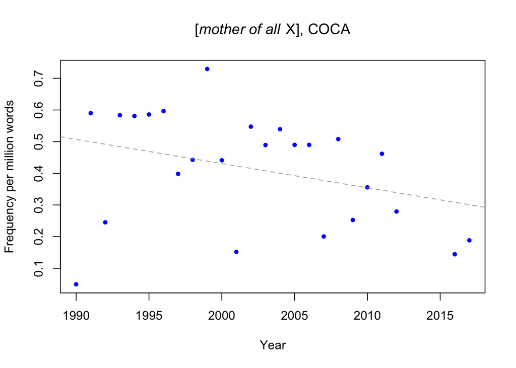

```r
# relative frequency ------------------------------------------------------

# get COCA frequencies
coca_freq <- read_xlsx("../COCA2017_total_frequencies.xlsx")

# tabulate mother frequency
moa_tbl <- table(moa$Year) %>% as.data.frame(stringsAsFactors = F)
colnames(moa_tbl) <- c("YEAR", "Freq")
moa_tbl$YEAR <- as.numeric(moa_tbl$YEAR)
moa_tbl <- left_join(coca_freq, moa_tbl, by = "YEAR")
moa_tbl$pmw <- (moa_tbl$Freq / moa_tbl$TOTAL) * 1e06

# plot
# png("mother_of_all_coca_freq.png", width = 6.5, height = 5, un = "in", res = 300)
plot(moa_tbl$YEAR, moa_tbl$pmw, pch = 20, col = "blue",
     ylab = "Frequency per million words", xlab = "Year",
     main = expression(paste("[", italic("mother of all"), " X], COCA")))
abline(lm(moa_tbl$pmw ~ moa_tbl$YEAR), lty = 2, col = "darkgrey")
```

```r
# dev.off()

# types per decade
moa_types <- moa %>% group_by(Decade) %>% summarise(
  types = length(unique(lemma)),
  n = n()
)

# types per year
moa_types_year <- moa %>% group_by(Year) %>% summarise(
  types = length(unique(lemma))
)


# add to table with total frequencies
moa_tbl <- left_join(moa_types_year, moa_tbl, by = c("Year" = "YEAR"))
moa_tbl <- rename(moa_tbl, "YEAR" = "Year")
moa_tbl$types_pmw <- (moa_tbl$types / moa_tbl$TOTAL) * 1e6

# coca_freq per dcade
coca_freq$Decade <- floor(coca_freq$YEAR/10)*10

coca_freq_decade <- coca_freq %>% group_by(Decade) %>% summarise(
  n = sum(TOTAL)
)

# types per decade
moa_types <- left_join(moa_types, coca_freq_decade)
```

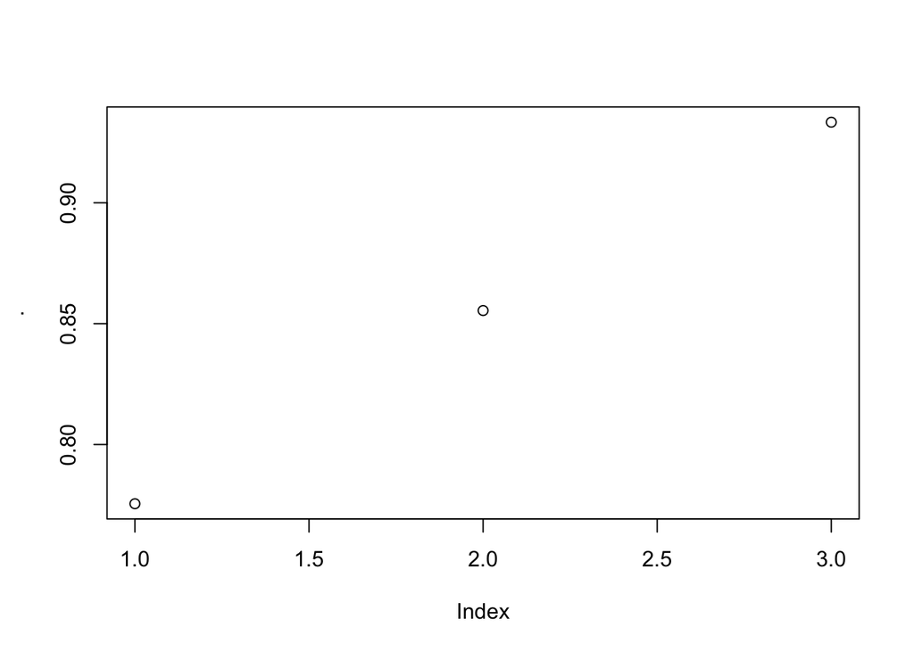

```r
moa_types$rel <- moa_types$types / moa_types$n
moa_types$rel %>% plot
```

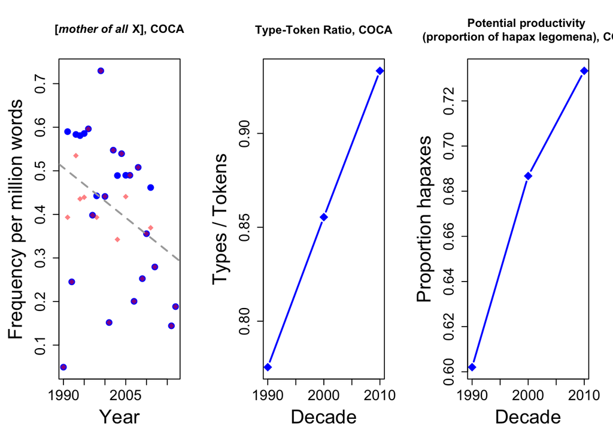

```r
moa_types$ttr <- moa_types$types / moa_types$n

# distribution of hapaxes
hapaxes <- table(moa$lemma) %>% as.data.frame %>% filter(Freq==1) %>% select(Var1) %>% as.vector
hapaxes <- as.character(hapaxes$Var1)
moa$hapax <- ifelse(moa$lemma %in% hapaxes, "y", "n")

moa_hapaxes <- moa %>% group_by(Decade) %>% summarise(
  hapaxes = length(which(hapax=="y")),
  n = n()
)

# plot potential productivity
moa_hapaxes$pp <- moa_hapaxes$hapaxes / moa_hapaxes$n

par(mfrow = c(1,3))
#png("types_tokens_mother_COCA.png", width = 12, height = 4, un = "in", res = 300)
par(mfrow=c(1,3))
par(mar = c(5.1, 5.1, 5.1, 2.1))
plot(moa_tbl$YEAR, moa_tbl$pmw, pch = 20, col = "blue",
     ylab = "Frequency per million words", xlab = "Year",
     main = expression(paste(bold("["), bolditalic("mother of all"), bold(" X], COCA"))),
     cex = 2, cex.lab = 2, cex.axis=1.5)
abline(lm(moa_tbl$pmw ~ moa_tbl$YEAR), lty = 2, col = "darkgrey", lwd = 2)
points(moa_tbl$YEAR, moa_tbl$types_pmw, col = rgb(1,0,0,.5), pch = 18, cex = 1.3)

plot(moa_types$Decade, moa_types$ttr,
     type = "b", pch=18,
     ylab = "Types / Tokens", xlab = "Decade",
     main = "Type-Token Ratio, COCA",
     lwd = 2, col = "blue", cex = 2, cex.lab = 2, cex.axis=1.5)

plot(moa_hapaxes$Decade, moa_hapaxes$pp, type = "b", pch=18,
     ylab = "Proportion hapaxes", xlab = "Decade",
     main = "Potential productivity \n (proportion of hapax legomena), COCA",
     lwd = 2, col = "blue", cex = 2, cex.lab = 2, cex.axis=1.5)
```

```r
# dev.off()
par(mar = c(5.1, 4.1, 4.1, 2.1))
par(mfrow=c(1,1))
```

[Back to top page](https://hartmast.github.io/Attack_of_the_snowclones/)